# **MELANOMA ANALYSIS**

*Emile Cohen*

*July 2020*

**Goal**: In this notebook, we want to understand what makes Melanoma an outlier for the patterns we saw, and what are the major subcohorts that drive the outlying signal.

```python
%run -i '../../../../../utils/setup_environment.ipy'

import warnings
warnings.filterwarnings('ignore')
from scipy.stats import fisher_exact, ranksums, chi2, norm
from statsmodels.sandbox.stats.multicomp import multipletests
import matplotlib.gridspec as gridspec
import pickle

data_path = '../../../../../data/'
data_wgd = data_path + 'impact-facets-tp53/processed/wgd/'
data_no_wgd = data_path + 'impact-facets-tp53/processed/no_wgd/'
```

```
Setup environment... done!
```

✅ Working on **mskimpact_env** conda environment.

```python
pwd
```

```
'/Users/cohene/repos/mskimpact_tp53_exploration/analysis/exploratory_analysis/cancer_exploration/outliers/melanoma'
```

## Interesting functions

```python
from functools import reduce

def get_hotspots(df: pd.DataFrame, Sample_Type: str, group: list = None, group_type:str = None):
    data = df[df['Sample_Type'] == Sample_Type]

    if group and group_type:
        data = data[data[group_type].isin(group)]

    data_1 = get_groupby(data,'tp53_spot_1', 'count'); data_2 = get_groupby(data,'tp53_spot_2', 'count'); data_3 = get_groupby(data,'tp53_spot_3', 'count') ; data_4 = get_groupby(data,'tp53_spot_4', 'count') ; data_5 = get_groupby(data,'tp53_spot_5', 'count')
    series_data = [data_1,data_2,data_3,data_4,data_5]

    df_merged = reduce(lambda  left,right: pd.merge(left,right,left_index=True, right_index=True,
                                                how='outer'), series_data).fillna(0)

    df_merged.columns = ['count_1', 'count_2', 'count_3', 'count_4', 'count_5']
    df_merged['total'] = df_merged.sum(axis=1)
    df_merged = df_merged.sort_values(by='total', ascending=False)

    df_merged = df_merged.drop('nan')

    return df_merged

def get_hotspot_frac(df: pd.DataFrame, group_type:str = None, group: list = None, nb = 10):
    if group_type and group:
        df = df[df[group_type].isin(group)]
    result = [['spot', '#', 'frac']]
    for spot in get_groupby(df, 'tp53_spot_1', 'count').sort_values(by='count', ascending=False).head(nb).index.tolist():
        result.append([spot,df[df['tp53_spot_1'] == spot].frac_genome_altered.shape[0], df[df['tp53_spot_1'] == spot].frac_genome_altered.median()])

    return pd.DataFrame(result)



def boxplot_sampletype(df: pd.DataFrame, group:str, palette, order, metrics: str, figsize= (10,3), title: str = '', title_font: int=12, xlim=[0,1]):
    fig=plt.figure(figsize=figsize)
    ax = plt.subplot2grid(shape=(2,1), loc=(0,0), colspan=1)

    sns.boxplot(y=metrics, x=group,data=df,ax=ax, dodge=False,order=order, palette=palette).set_title(title, weight='bold', fontsize=title_font)

    groupby_ = get_groupby(df,group, 'count')
    groupby_ = groupby_.T
    for mut in mutation_list:
        if mut not in groupby_.columns:
            groupby_[mut] = 0
    groupby_ = groupby_.T

    labels = []
    for element in order:
        labels.append(element + '\n('+ str(groupby_.loc[element].values[0])+')')



    ax.set_xticklabels(labels)
    style(ax)
    ax.set_ylim(xlim)
    ax.spines['right'].set_visible(False)
    ax.spines['top'].set_visible(False)

    return fig, ax
# Let's give a look at medians and statistics

def get_statistics(df: pd.DataFrame, group:str, metrics: str, group_list: list):
    group_1 = df[df[group] == group_list[0]][metrics]
    group_2 = df[df[group] == group_list[1]][metrics]

    median_1 = group_1.median()
    median_2 = group_2.median()

    statistic, p_value = ranksums(group_1.dropna().values,group_2.dropna().values)

    results = [['', 'size', metrics],
               [group_list[0], group_1.shape[0], median_1],
               [group_list[1], group_2.shape[0], median_2],
               ['', 'Statistics', 'p-value'],
               ['', statistic, p_value]]


    return pd.DataFrame(results)

def get_major_codrivers(master: pd.DataFrame, maf: pd.DataFrame, head:int = 10, tp53=False):
    samples = master.Tumor_Id.tolist()
    if tp53:
        maf_filtered = maf[maf.Tumor_Sample_Barcode.isin(samples)][maf['driver'] == True]
    else:
        maf_filtered = maf[maf.Tumor_Sample_Barcode.isin(samples)][maf['driver'] == True][maf['Hugo_Symbol'] != 'TP53']
    h = pd.DataFrame(maf_filtered[['Hugo_Symbol']].groupby(['Hugo_Symbol']).size())
    h.columns = ['count']
    h = h.sort_values(by='count', ascending=False).head(head)

    return(h)



def create_co_drivers_table(master: pd.DataFrame, group_type:str,  group_1: str, group_2: str):
    master_group_1 = master[master[group_type] == group_1]
    co_drivers_group_1 = get_major_codrivers(master=master_group_1,
                        maf=maf_cohort_nowgd,
                       head=100)
    co_drivers_group_1['proportion_1'] = co_drivers_group_1.apply(lambda x: 100* round(x['count'] / co_drivers_group_1.sum().values[0], 4), axis=1)

    master_group_2 = master[master[group_type] == group_2]
    co_drivers_group_2 = get_major_codrivers(master=master_group_2,
                        maf=maf_cohort_nowgd,
                       head=100)
    co_drivers_group_2['proportion_2'] = co_drivers_group_2.apply(lambda x: 100* round(x['count'] / co_drivers_group_2.sum().values[0], 4), axis=1)

    co_drivers_groups = pd.merge(co_drivers_group_1, co_drivers_group_2, on='Hugo_Symbol')
    co_drivers_groups['proportion_1'] = - co_drivers_groups['proportion_1']

    return co_drivers_groups
```

## Master Definition and Filtering

```python
cancer='Melanoma'
```

```python
master_no_wgd = non_wgd_load_and_cut(data_path + 'impact-facets-tp53/processed/no_wgd/master_no_wgd.pkl')
master_wgd = pd.read_pickle(data_path + 'impact-facets-tp53/processed/wgd/master_wgd.pkl')


master_no_wgd_cancer = master_no_wgd[master_no_wgd['Cancer_Type'] == cancer]
master_wgd_cancer = master_wgd[master_wgd['Cancer_Type'] == cancer]

maf_cohort_nowgd = pd.read_csv(data_path + 'impact-facets-tp53/processed/no_wgd/maf_cohort_nowgd.txt', sep='\t').drop('Unnamed: 0', axis=1)
maf_cohort_wgd = pd.read_csv(data_path + 'impact-facets-tp53/processed/wgd/maf_cohort_wgd.txt', sep='\t').drop('Unnamed: 0', axis=1)
```

# What makes Melanoma an Outlier?

## WGD Proportion

Melanoma has a proportion of WGD around 25%

[figure not shown]

## Cancer Panel - Non WGD Cohort

[figure not shown]

- Melanoma is enriched in Metastatic Samples, in *0_HETLOSS* subgroup.
- The proportion of tp53 mutation is low: 32.7%

## Genome Instability

[figure not shown]

Melanoma is one of the three cancers that shows an outlying signal in Genome Instability Pattern: while almost all cancers have a correlation between tp53 bi allelic state, Glioma, Pancreatic Cancer an d Melanoma do not show this GI difference.

[figure not shown]

- 0_HETLOSS is as high as >=1_LOSS

# WGD Part

## Subgroup Proportion

We observe the same pattern as in Non WGD Cohort: high proportion of Non Tp53 mutated / No LOH samples (in blue)

[figure not shown]

## Very High Genome Instability

In WGD cohort, Genome Instability median is above 70% for all cancer types.

[figure not shown]

# Non WGD Part - Cancer Investigation

In this section, our goal is to find subcohorts that lead the signals observed. Here are the different subcohort we will create:

- Hotspot Analysis: splitting on 273 / 248 / 175 / Missense / Truncated / In Frame
- CCF Analysis
- SNV/INDEL Analysis

## Hotspot Analysis

In this section, we cut our cohort to only keep samples with exactly one TP53 mutation, for simplicity.

```python
master_hotspot = master_no_wgd_cancer[master_no_wgd_cancer['tp53_count'] == 1]
```

```python
get_hotspot_frac(df=master_hotspot,
                group_type=None,
                group=None)
```

|  | 0 | 1 | 2 |
| --- | --- | --- | --- |
| 0 | spot | # | frac |
| 1 | nan | 8 | 0.372 |
| 2 | 241 | 4 | 0.325 |
| 3 | 177 | 3 | 0.442 |
| 4 | 248 | 3 | 0.223 |
| 5 | 245 | 3 | 0.285 |
| 6 | 179 | 3 | 0.221 |
| 7 | 278 | 2 | 0.4075 |
| 8 | 213 | 2 | 0.389 |
| 9 | 342 | 2 | 0.212 |
| 10 | 127 | 2 | 0.5605 |

### Entire Cohort

```python
h = get_groupby(master_hotspot,'tp53_vc_group_1', 'count').sort_values(by='count', ascending=False)
display(h)

h = h.T
h = h[mutation_list]
fig = plt.figure(figsize=(6,1))
ax = plt.subplot()

ax.spines['right'].set_visible(False)
ax.spines['top'].set_visible(False)

h_plot = h.plot(kind = 'barh', stacked=True, yticks=[], ax=ax, colormap="Accent")
ax.legend(['In Frame', 'Truncated', 'Missense', 'Hotspot 248','Hotspot 273','Hotspot 175', 'Other Hotspot'],loc='center left', bbox_to_anchor=(1.2, 0.5), fontsize=11)
ax.set_title('Mutation Type - {} - No WGD'.format(cancer), weight='bold', fontsize=18)

plt.show()
```

| tp53_vc_group_1 | count |
| --- | --- |
| missense | 35 |
| truncated | 24 |
| hotspot | 4 |
| 248 | 3 |
| in_frame | 2 |

[output not shown]

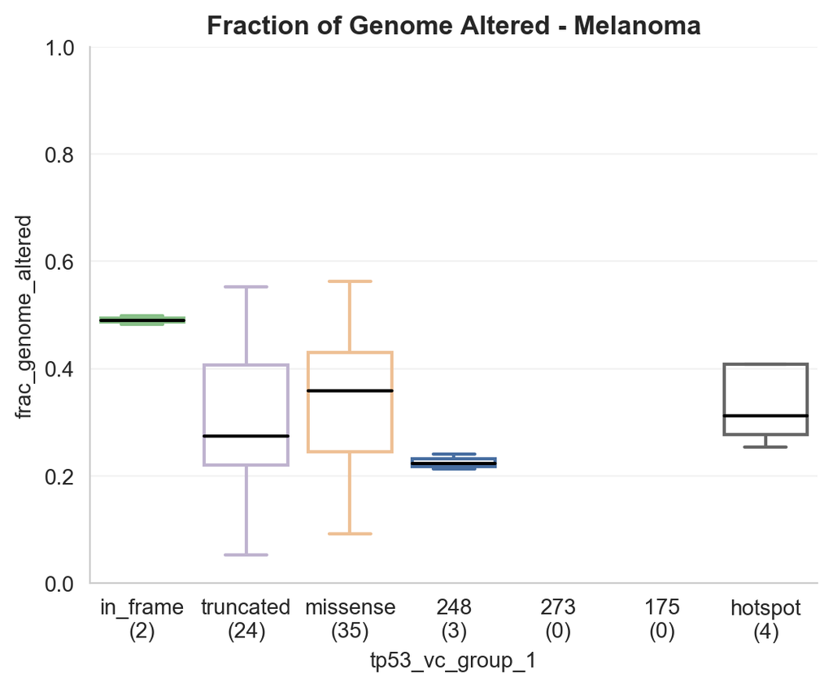

```python
fig, ax = boxplot_sampletype(df=master_hotspot,
                  group='tp53_vc_group_1',
                  palette=mutation_palette,
                  order=mutation_list,
                  metrics='frac_genome_altered',
                  figsize=(6,10),
                  title='Fraction of Genome Altered - {}'.format(cancer),
                  xlim=[0,1])
plt.show()
```

### TP53 Residual Subgroups

```python
print('Number of Bi Allelic samples (with 1 mut): ' + str(master_hotspot[master_hotspot['tp53_res_group'] == 'no_tp53_res'].shape[0]))
print('')
print('Number of  TP53 Residual samples (with 1 mut): ' + str(master_hotspot[master_hotspot['tp53_res_group'] == 'tp53_res'].shape[0]))
```

```
Number of Bi Allelic samples (with 1 mut): 55

Number of  TP53 Residual samples (with 1 mut): 10
```

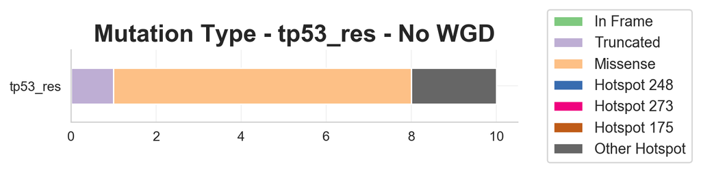

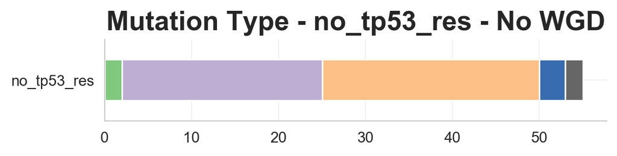

| tp53_vc_group_1 | tp53_res |
| --- | --- |
| missense | 7 |
| hotspot | 2 |
| truncated | 1 |

| tp53_vc_group_1 | no_tp53_res |
| --- | --- |
| missense | 25 |
| truncated | 23 |
| 248 | 3 |
| hotspot | 2 |
| in_frame | 2 |

```python
total_df = []
for group in ['tp53_res', 'no_tp53_res']:
    h = get_groupby(master_hotspot[master_hotspot['tp53_res_group'] == group], 'tp53_vc_group_1', group).sort_values(by=group, ascending=False)
    total_df.append(h)

    h=h.T

    for mut in mutation_list:
        if mut not in h.columns:
            h[mut] = 0

    h = h[mutation_list]
    fig = plt.figure(figsize=(6,1))
    ax = plt.subplot()

    ax.spines['right'].set_visible(False)
    ax.spines['top'].set_visible(False)

    h_plot = h.plot(kind = 'barh', stacked=True, yticks=[], ax=ax, colormap="Accent")
    if group == 'tp53_res':
        ax.legend(['In Frame', 'Truncated', 'Missense', 'Hotspot 248','Hotspot 273','Hotspot 175', 'Other Hotspot'],loc='center left', bbox_to_anchor=(1.05, 0.5), fontsize=11)
    else: ax.get_legend().remove()
    ax.set_title('Mutation Type - {} - No WGD'.format(group), weight='bold', fontsize=18)

    plt.show()

display_side_by_side(total_df[0],total_df[1])
```

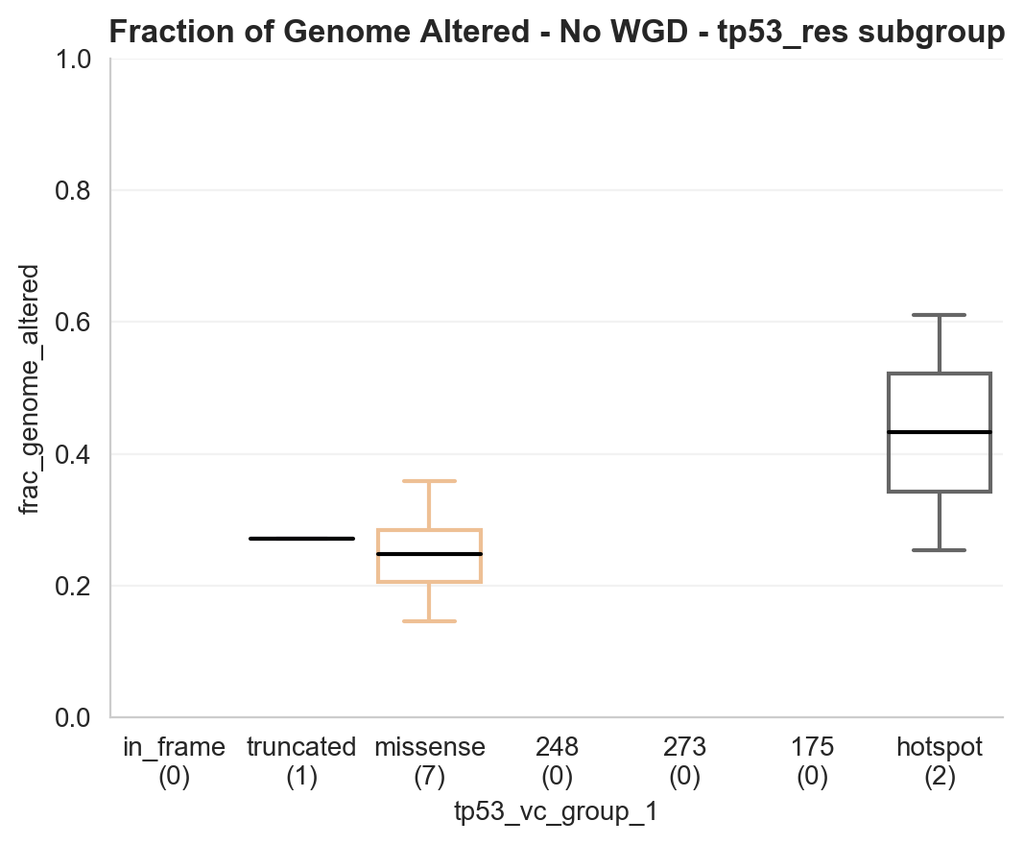

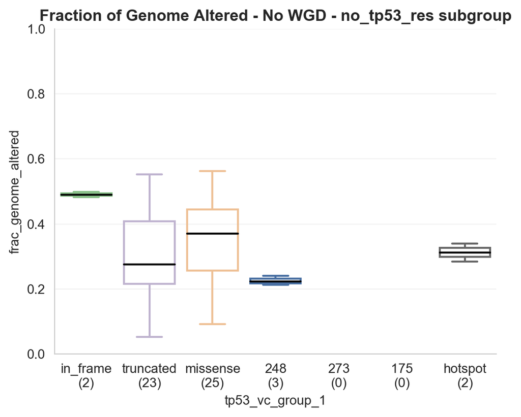

```python
for group in ['tp53_res', 'no_tp53_res']:
    master_wt = master_hotspot[master_hotspot['tp53_res_group'] == group]

    fig, ax = boxplot_sampletype(df=master_wt,
                      group='tp53_vc_group_1',
                      palette=mutation_palette,
                      order=mutation_list,
                      metrics='frac_genome_altered',
                      figsize=(6,10),
                      title='Fraction of Genome Altered - No WGD - {} subgroup'.format(group),
                      xlim=[0,1])
    plt.show()
```

## SNV / INDEL Analysis

### # of Drivers / SNV Drivers / INDEL Drivers

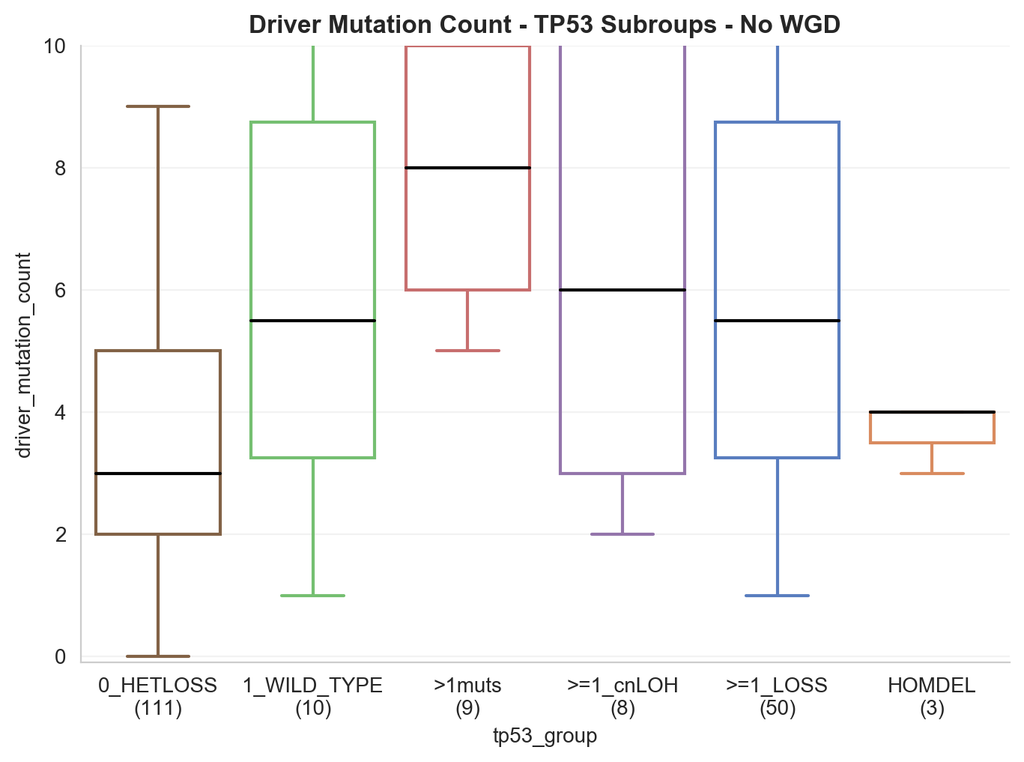

|  | 0 | 1 | 2 |
| --- | --- | --- | --- |
| 0 |  | size | driver_mutation_count |
| 1 | 1_WILD_TYPE | 10 | 5.5 |
| 2 | 0_HETLOSS | 111 | 3 |
| 3 |  | Statistics | p-value |
| 4 |  | 1.97212 | 0.048596 |

|  | 0 | 1 | 2 |
| --- | --- | --- | --- |
| 0 |  | size | driver_mutation_count |
| 1 | 1_WILD_TYPE | 10 | 5.5 |
| 2 | >=1_LOSS | 50 | 5.5 |
| 3 |  | Statistics | p-value |
| 4 |  | -0.247942 | 0.804179 |

|  | 0 | 1 | 2 |
| --- | --- | --- | --- |
| 0 |  | size | driver_mutation_count |
| 1 | >1muts | 9 | 8 |
| 2 | >=1_LOSS | 50 | 5.5 |
| 3 |  | Statistics | p-value |
| 4 |  | 2.05548 | 0.0398326 |

```python
fig, ax = boxplot_sampletype(df=master_no_wgd_cancer,
                  group='tp53_group',
                  palette=palette,
                  order=group_list,
                  metrics='driver_mutation_count',
                  figsize=(8,12),
                  title='Driver Mutation Count - TP53 Subroups - No WGD',
                  xlim=[-0.1,10])
plt.show()

display_side_by_side(get_statistics(df=master_no_wgd_cancer,
               group='tp53_group',
               metrics='driver_mutation_count',
               group_list=['1_WILD_TYPE', '0_HETLOSS']),

       get_statistics(df=master_no_wgd_cancer,
               group='tp53_group',
               metrics='driver_mutation_count',
               group_list=['1_WILD_TYPE', '>=1_LOSS']),

       get_statistics(df=master_no_wgd_cancer,
               group='tp53_group',
               metrics='driver_mutation_count',
               group_list=['>1muts', '>=1_LOSS']))
```

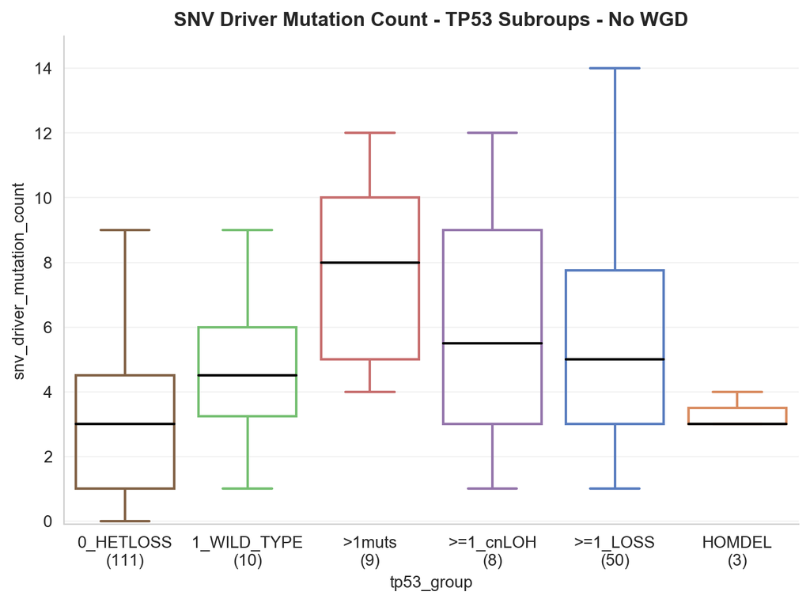

|  | 0 | 1 | 2 |
| --- | --- | --- | --- |
| 0 |  | size | snv_driver_mutation_count |
| 1 | 1_WILD_TYPE | 10 | 4.5 |
| 2 | 0_HETLOSS | 111 | 3 |
| 3 |  | Statistics | p-value |
| 4 |  | 1.92976 | 0.0536367 |

|  | 0 | 1 | 2 |
| --- | --- | --- | --- |
| 0 |  | size | snv_driver_mutation_count |
| 1 | 1_WILD_TYPE | 10 | 4.5 |
| 2 | >=1_LOSS | 50 | 5 |
| 3 |  | Statistics | p-value |
| 4 |  | -0.38679 | 0.698912 |

|  | 0 | 1 | 2 |
| --- | --- | --- | --- |
| 0 |  | size | snv_driver_mutation_count |
| 1 | >1muts | 9 | 8 |
| 2 | >=1_LOSS | 50 | 5 |
| 3 |  | Statistics | p-value |
| 4 |  | 2.02386 | 0.0429848 |

```python
fig, ax = boxplot_sampletype(df=master_no_wgd_cancer,
                  group='tp53_group',
                  palette=palette,
                  order=group_list,
                  metrics='snv_driver_mutation_count',
                  figsize=(8,12),
                  title='SNV Driver Mutation Count - TP53 Subroups - No WGD',
                  xlim=[-0.1,15])
plt.show()

display_side_by_side(get_statistics(df=master_no_wgd_cancer,
               group='tp53_group',
               metrics='snv_driver_mutation_count',
               group_list=['1_WILD_TYPE', '0_HETLOSS']),

       get_statistics(df=master_no_wgd_cancer,
               group='tp53_group',
               metrics='snv_driver_mutation_count',
               group_list=['1_WILD_TYPE', '>=1_LOSS']),

       get_statistics(df=master_no_wgd_cancer,
               group='tp53_group',
               metrics='snv_driver_mutation_count',
               group_list=['>1muts', '>=1_LOSS']))
```

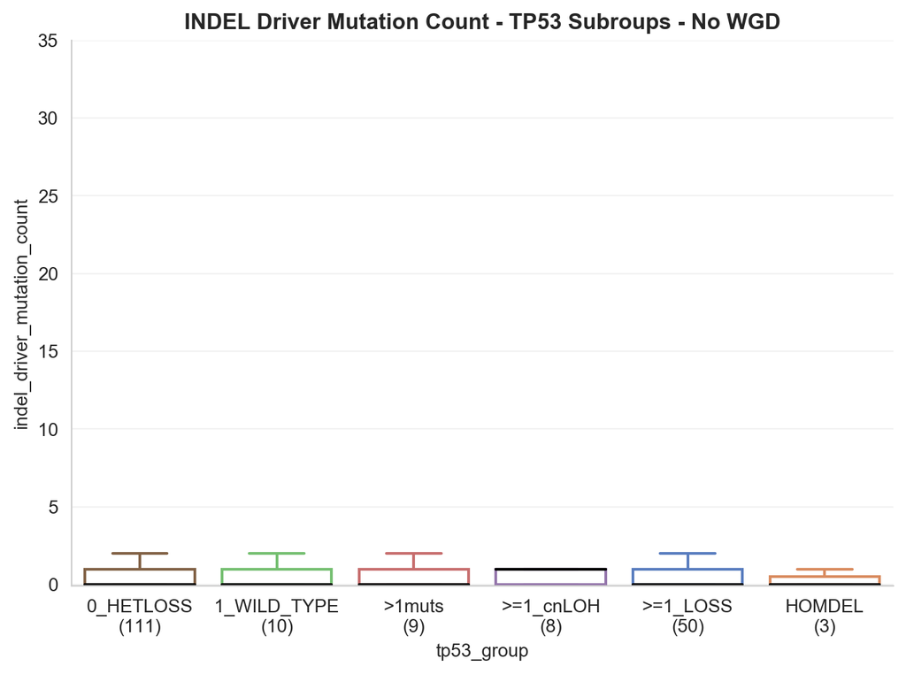

|  | 0 | 1 | 2 |
| --- | --- | --- | --- |
| 0 |  | size | indel_driver_mutation_count |
| 1 | 1_WILD_TYPE | 10 | 0 |
| 2 | 0_HETLOSS | 111 | 0 |
| 3 |  | Statistics | p-value |
| 4 |  | 0.621288 | 0.53441 |

|  | 0 | 1 | 2 |
| --- | --- | --- | --- |
| 0 |  | size | indel_driver_mutation_count |
| 1 | 1_WILD_TYPE | 10 | 0 |
| 2 | >=1_LOSS | 50 | 0 |
| 3 |  | Statistics | p-value |
| 4 |  | 0.0892592 | 0.928876 |

|  | 0 | 1 | 2 |
| --- | --- | --- | --- |
| 0 |  | size | indel_driver_mutation_count |
| 1 | >1muts | 9 | 0 |
| 2 | >=1_LOSS | 50 | 0 |
| 3 |  | Statistics | p-value |
| 4 |  | -0.400555 | 0.688748 |

```python
fig, ax = boxplot_sampletype(df=master_no_wgd_cancer,
                  group='tp53_group',
                  palette=palette,
                  order=group_list,
                  metrics='indel_driver_mutation_count',
                  figsize=(8,12),
                  title='INDEL Driver Mutation Count - TP53 Subroups - No WGD',
                  xlim=[-0.1,35])
plt.show()

display_side_by_side(get_statistics(df=master_no_wgd_cancer,
               group='tp53_group',
               metrics='indel_driver_mutation_count',
               group_list=['1_WILD_TYPE', '0_HETLOSS']),

       get_statistics(df=master_no_wgd_cancer,
               group='tp53_group',
               metrics='indel_driver_mutation_count',
               group_list=['1_WILD_TYPE', '>=1_LOSS']),

       get_statistics(df=master_no_wgd_cancer,
               group='tp53_group',
               metrics='indel_driver_mutation_count',
               group_list=['>1muts', '>=1_LOSS']))
```

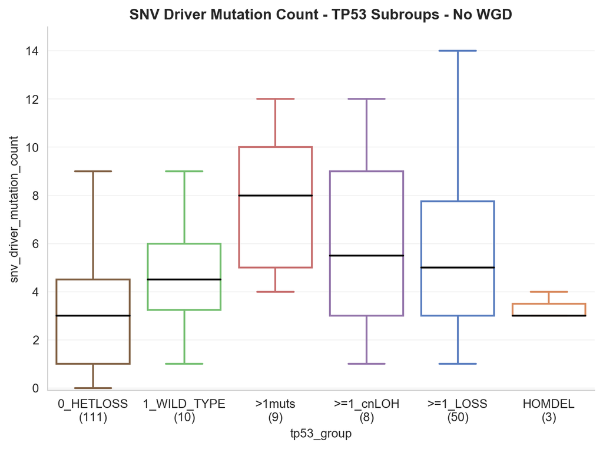

|  | 0 | 1 | 2 |
| --- | --- | --- | --- |
| 0 |  | size | snv_driver_mutation_count |
| 1 | 1_WILD_TYPE | 10 | 4.5 |
| 2 | 0_HETLOSS | 111 | 3 |
| 3 |  | Statistics | p-value |
| 4 |  | 1.92976 | 0.0536367 |

|  | 0 | 1 | 2 |
| --- | --- | --- | --- |
| 0 |  | size | snv_driver_mutation_count |
| 1 | 1_WILD_TYPE | 10 | 4.5 |
| 2 | >=1_LOSS | 50 | 5 |
| 3 |  | Statistics | p-value |
| 4 |  | -0.38679 | 0.698912 |

|  | 0 | 1 | 2 |
| --- | --- | --- | --- |
| 0 |  | size | snv_driver_mutation_count |
| 1 | >1muts | 9 | 8 |
| 2 | >=1_LOSS | 50 | 5 |
| 3 |  | Statistics | p-value |
| 4 |  | 2.02386 | 0.0429848 |

```python
fig, ax = boxplot_sampletype(df=master_no_wgd_cancer,
                  group='tp53_group',
                  palette=palette,
                  order=group_list,
                  metrics='snv_driver_mutation_count',
                  figsize=(8,12),
                  title='SNV Driver Mutation Count - TP53 Subroups - No WGD',
                  xlim=[-0.1,15])
plt.show()

display_side_by_side(get_statistics(df=master_no_wgd_cancer,
               group='tp53_group',
               metrics='snv_driver_mutation_count',
               group_list=['1_WILD_TYPE', '0_HETLOSS']),

       get_statistics(df=master_no_wgd_cancer,
               group='tp53_group',
               metrics='snv_driver_mutation_count',
               group_list=['1_WILD_TYPE', '>=1_LOSS']),

       get_statistics(df=master_no_wgd_cancer,
               group='tp53_group',
               metrics='snv_driver_mutation_count',
               group_list=['>1muts', '>=1_LOSS']))
```

Here, one major information:

- There are differences in # of Co-Drivers
  - This signal is led by SNV Co-Drivers

### Genome Instability

The idea here is to see if we have differences in Fraction of Genome Altered if we cut our Cancer cohort on the number of drivers per sample.

#### 1_WILD_TYPE Subgroup

```python
master_no_wgd_cancer_wt = master_no_wgd_cancer[master_no_wgd_cancer['tp53_group'] == '1_WILD_TYPE']

thr=5

def get_driver_groups(x):
    if x.driver_mutation_count > thr:
        return 'High Co-Driver Count'
    if x.driver_mutation_count <= thr:
        return 'Low Co-Driver Count'


master_no_wgd_cancer_wt['co_driver_group'] = master_no_wgd_cancer_wt.apply(get_driver_groups, axis=1)
```

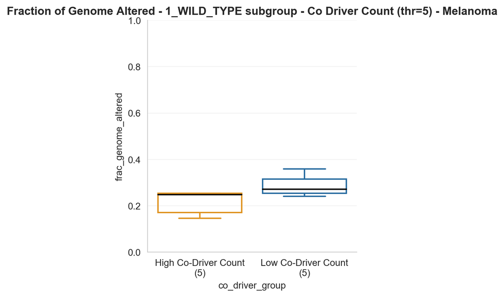

|  | 0 | 1 | 2 |
| --- | --- | --- | --- |
| 0 |  | size | frac_genome_altered |
| 1 | High Co-Driver Count | 5 | 0.248 |
| 2 | Low Co-Driver Count | 5 | 0.272 |
| 3 |  | Statistics | p-value |
| 4 |  | -1.04447 | 0.29627 |

```python
fig, ax = boxplot_sampletype(df=master_no_wgd_cancer_wt,
                  group='co_driver_group',
                  palette={'High Co-Driver Count': '#FF9900' , 'Low Co-Driver Count': '#146EB4'},
                  order=['High Co-Driver Count', 'Low Co-Driver Count'],
                  metrics='frac_genome_altered',
                  figsize=(4,10),
                  title='Fraction of Genome Altered - 1_WILD_TYPE subgroup - Co Driver Count (thr={}) - {}'.format(thr,cancer),
                  xlim=[0,1])
plt.show()

get_statistics(df=master_no_wgd_cancer_wt,
               group='co_driver_group',
               metrics='frac_genome_altered',
               group_list=['High Co-Driver Count', 'Low Co-Driver Count'])
```

#### 0_HETLOSS

```python
master_no_wgd_cancer_het = master_no_wgd_cancer[master_no_wgd_cancer['tp53_group'] == '0_HETLOSS']

thr=3

def get_driver_groups(x):
    if x.driver_mutation_count > thr:
        return 'High Co-Driver Count'
    if x.driver_mutation_count <= thr:
        return 'Low Co-Driver Count'


master_no_wgd_cancer_het['co_driver_group'] = master_no_wgd_cancer_het.apply(get_driver_groups, axis=1)
```

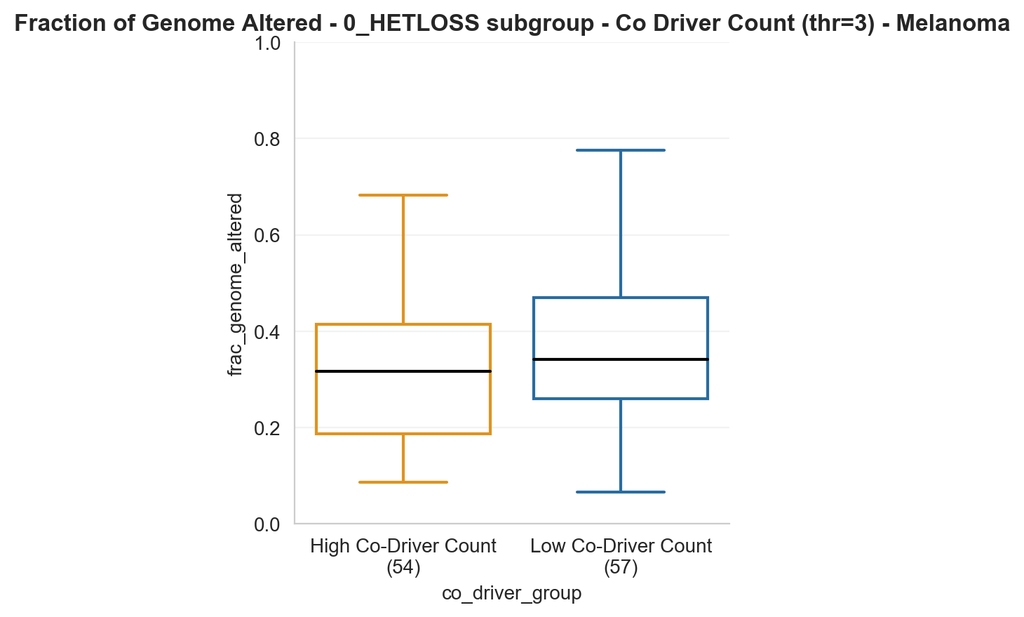

|  | 0 | 1 | 2 |
| --- | --- | --- | --- |
| 0 |  | size | frac_genome_altered |
| 1 | High Co-Driver Count | 54 | 0.317 |
| 2 | Low Co-Driver Count | 57 | 0.341 |
| 3 |  | Statistics | p-value |
| 4 |  | -1.82603 | 0.0678457 |

```python
fig, ax = boxplot_sampletype(df=master_no_wgd_cancer_het,
                  group='co_driver_group',
                  palette={'High Co-Driver Count': '#FF9900' , 'Low Co-Driver Count': '#146EB4'},
                  order=['High Co-Driver Count', 'Low Co-Driver Count'],
                  metrics='frac_genome_altered',
                  figsize=(4,10),
                  title='Fraction of Genome Altered - 0_HETLOSS subgroup - Co Driver Count (thr={}) - {}'.format(thr,cancer),
                  xlim=[0,1])
plt.show()

get_statistics(df=master_no_wgd_cancer_het,
               group='co_driver_group',
               metrics='frac_genome_altered',
               group_list=['High Co-Driver Count', 'Low Co-Driver Count'])
```

## Co Driver Analysis

```python
codrivers_glioma = get_major_codrivers(master=master_no_wgd_cancer,
                    maf=maf_cohort_nowgd,
                    head=15)

codrivers_glioma_tp53 = get_major_codrivers(master=master_no_wgd_cancer[master_no_wgd_cancer['tp53_count'] >= 1],
                    maf=maf_cohort_nowgd,
                    head=15)
```

```python
co_drivers = pd.merge(codrivers_glioma, codrivers_glioma_tp53, on='Hugo_Symbol')
co_drivers.columns = ['cancer', 'cancer_tp53']
```

```python
co_drivers['ratio'] = co_drivers.apply(lambda x: 100*round(x.cancer_tp53/x.cancer, 4) , axis=1)
co_drivers = co_drivers.sort_values(by='ratio', ascending=False)
```

```python
co_drivers
```

| Hugo_Symbol | cancer | cancer_tp53 | ratio |
| --- | --- | --- | --- |
| NF1 | 158 | 51 | 32.28 |
| PTPRT | 36 | 10 | 27.78 |
| ARID2 | 86 | 23 | 26.74 |
| TP63 | 35 | 9 | 25.71 |
| CDKN2A | 92 | 23 | 25.00 |
| KIT | 37 | 9 | 24.32 |
| TERT | 418 | 74 | 17.70 |
| NRAS | 162 | 17 | 10.49 |
| BRAF | 206 | 16 | 7.77 |

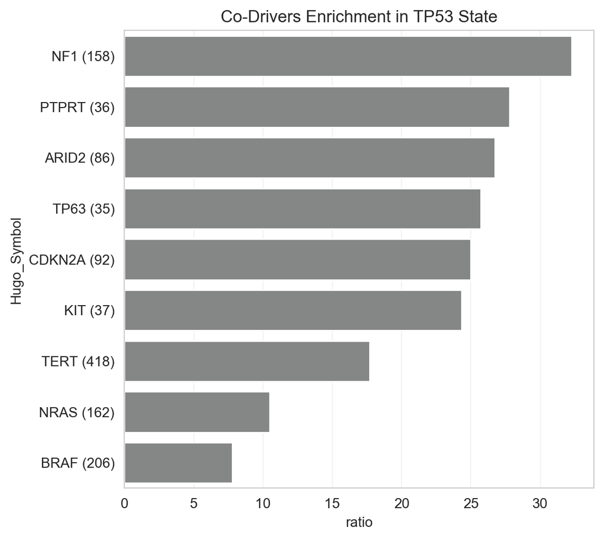

```python
labels = []
for element in co_drivers.index.tolist():
    labels.append(element + ' ('+ str(int(co_drivers.loc[element]['cancer']))+')')

ax = sns.barplot(y=co_drivers.index, x='ratio',data=co_drivers[['ratio']], color='#7F8C8D', saturation=.2)
ax.set_yticklabels(labels)
ax.set_title('Co-Drivers Enrichment in TP53 State')
```

```python
codrivers_glioma
```

| Hugo_Symbol | count |
| --- | --- |
| TERT | 418 |
| BRAF | 206 |
| NRAS | 162 |
| NF1 | 158 |
| CDKN2A | 92 |
| ARID2 | 86 |
| SF3B1 | 61 |
| PTEN | 59 |
| GNAQ | 47 |
| BAP1 | 42 |
| MAP2K1 | 41 |
| GNA11 | 41 |
| KIT | 37 |
| PTPRT | 36 |
| TP63 | 35 |

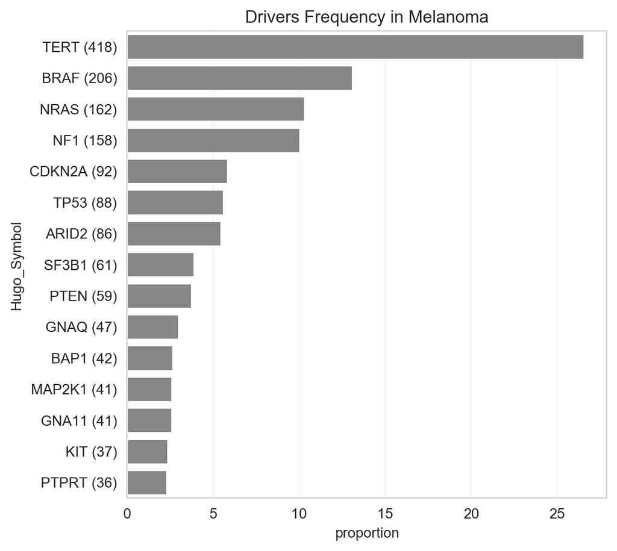

```python
labels = []
codrivers_glioma = get_major_codrivers(master=master_no_wgd_cancer,
                                       maf=maf_cohort_nowgd,
                                       head=15,
                                       tp53=True)

codrivers_glioma['proportion'] = codrivers_glioma.apply(lambda x: 100* round(x['count'] / codrivers_glioma.sum().values[0], 4), axis=1)

for element in codrivers_glioma.head(15).index.tolist():
    labels.append(element + ' ('+ str(int(codrivers_glioma.loc[element]['count']))+')')

ax = sns.barplot(y=codrivers_glioma.head(15).index, x='proportion',data=codrivers_glioma.head(15)[['proportion']], color='#7F8C8D', saturation=.2)
ax.set_yticklabels(labels)
ax.set_title('Drivers Frequency in {}'.format(cancer))
```

### Co-Drivers per subgroup

```python
co_drivers_res = create_co_drivers_table(master=master_no_wgd_cancer,
                                                group_type='tp53_res_group',
                                                group_1='tp53_res',
                                                group_2='no_tp53_res')
co_drivers_res
```

| Hugo_Symbol | count_x | proportion_1 | count_y | proportion_2 |
| --- | --- | --- | --- | --- |
| TERT | 82 | -16.98 | 61 | 13.77 |
| NRAS | 52 | -10.77 | 12 | 2.71 |
| NF1 | 32 | -6.63 | 45 | 10.16 |
| BRAF | 27 | -5.59 | 11 | 2.48 |
| CDKN2A | 22 | -4.55 | 18 | 4.06 |
| ARID2 | 18 | -3.73 | 20 | 4.51 |
| PTPRT | 8 | -1.66 | 10 | 2.26 |
| ARID1A | 7 | -1.45 | 4 | 0.90 |
| PBRM1 | 7 | -1.45 | 4 | 0.90 |
| MAP2K1 | 7 | -1.45 | 5 | 1.13 |
| TP63 | 7 | -1.45 | 9 | 2.03 |
| RB1 | 6 | -1.24 | 6 | 1.35 |
| KIT | 6 | -1.24 | 5 | 1.13 |
| B2M | 6 | -1.24 | 2 | 0.45 |
| KRAS | 5 | -1.04 | 3 | 0.68 |
| FLT3 | 5 | -1.04 | 8 | 1.81 |
| PTEN | 5 | -1.04 | 5 | 1.13 |
| EPHA3 | 5 | -1.04 | 3 | 0.68 |
| SF3B1 | 5 | -1.04 | 1 | 0.23 |
| FAT1 | 4 | -0.83 | 3 | 0.68 |
| KMT2A | 4 | -0.83 | 8 | 1.81 |
| KMT2B | 4 | -0.83 | 6 | 1.35 |
| ATRX | 4 | -0.83 | 5 | 1.13 |
| HRAS | 3 | -0.62 | 3 | 0.68 |
| GNA11 | 3 | -0.62 | 1 | 0.23 |
| STK19 | 3 | -0.62 | 4 | 0.90 |
| RAC1 | 3 | -0.62 | 2 | 0.45 |
| BRCA2 | 3 | -0.62 | 3 | 0.68 |
| PTPRD | 3 | -0.62 | 12 | 2.71 |
| MGA | 3 | -0.62 | 4 | 0.90 |
| TET2 | 3 | -0.62 | 6 | 1.35 |
| SETD2 | 3 | -0.62 | 5 | 1.13 |
| SPRED1 | 3 | -0.62 | 2 | 0.45 |
| NOTCH4 | 2 | -0.41 | 3 | 0.68 |
| KDR | 2 | -0.41 | 4 | 0.90 |
| KMT2D | 2 | -0.41 | 1 | 0.23 |
| NOTCH1 | 2 | -0.41 | 3 | 0.68 |
| FAM58A | 2 | -0.41 | 3 | 0.68 |
| GRIN2A | 2 | -0.41 | 8 | 1.81 |
| APC | 2 | -0.41 | 3 | 0.68 |
| ARID1B | 2 | -0.41 | 2 | 0.45 |
| ATM | 2 | -0.41 | 4 | 0.90 |
| CBL | 2 | -0.41 | 7 | 1.58 |
| SPEN | 2 | -0.41 | 4 | 0.90 |
| CDK4 | 2 | -0.41 | 2 | 0.45 |
| RAF1 | 2 | -0.41 | 3 | 0.68 |
| ERBB2 | 2 | -0.41 | 2 | 0.45 |
| RNF43 | 2 | -0.41 | 2 | 0.45 |
| SMARCA4 | 1 | -0.21 | 1 | 0.23 |
| PTPN11 | 1 | -0.21 | 3 | 0.68 |
| TGFBR2 | 1 | -0.21 | 4 | 0.90 |
| PIK3R1 | 1 | -0.21 | 2 | 0.45 |
| SDHA | 1 | -0.21 | 1 | 0.23 |
| DICER1 | 1 | -0.21 | 2 | 0.45 |
| CRLF2 | 1 | -0.21 | 1 | 0.23 |
| CDK12 | 1 | -0.21 | 2 | 0.45 |

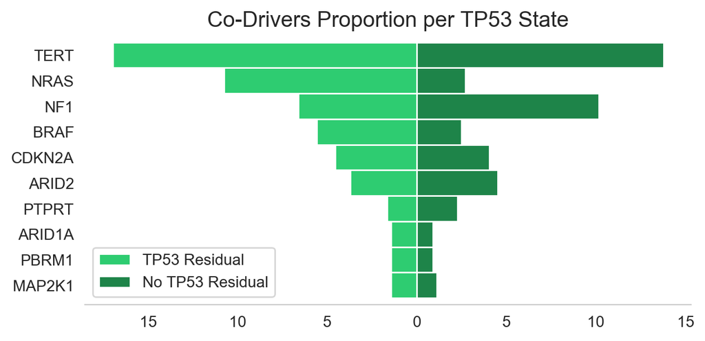

```python
fig=plt.figure(figsize=(7,7))
ax = plt.subplot2grid(shape=(2,1), loc=(0,0), colspan=1)
ax.spines['right'].set_visible(False)
ax.spines['left'].set_visible(False)
ax.spines['top'].set_visible(False)

co_drivers_res[['proportion_1', 'proportion_2']].head(10)[::-1].plot.barh(stacked=True, ax=ax, width=1, color = ['#2ECC71','#1E8449'])
ax.legend(['TP53 Residual', 'No TP53 Residual'], fontsize=10)
ax.set_title('Co-Drivers Proportion per TP53 State', fontsize=14)

plt.yticks(fontsize=10)
ax.set_ylabel('')
a=ax.get_xticks().tolist()
a = [20, 15, 10, 5, 0, 5, 10, 15, 20]
ax.set_xticklabels(a, fontsize=10)
plt.grid(b=None)

plt.show()
```

```python
co_drivers_cnloh_loss = create_co_drivers_table(master=master_no_wgd_cancer,
                                                group_type='tp53_group',
                                                group_1='>=1_cnLOH',
                                                group_2='>=1_LOSS')
co_drivers_cnloh_loss
```

| Hugo_Symbol | count_x | proportion_1 | count_y | proportion_2 |
| --- | --- | --- | --- | --- |
| NF1 | 8 | -14.55 | 30 | 9.43 |
| TERT | 7 | -12.73 | 43 | 13.52 |
| ARID2 | 3 | -5.45 | 14 | 4.40 |
| GRIN2A | 3 | -5.45 | 2 | 0.63 |
| TP63 | 2 | -3.64 | 7 | 2.20 |
| BRAF | 2 | -3.64 | 9 | 2.83 |
| CDKN2A | 2 | -3.64 | 13 | 4.09 |
| ARID1A | 2 | -3.64 | 2 | 0.63 |
| PTPRD | 2 | -3.64 | 6 | 1.89 |
| POLD1 | 1 | -1.82 | 1 | 0.31 |
| PBRM1 | 1 | -1.82 | 3 | 0.94 |
| PIK3R1 | 1 | -1.82 | 1 | 0.31 |
| RB1 | 1 | -1.82 | 2 | 0.63 |
| SPRED1 | 1 | -1.82 | 1 | 0.31 |
| STK19 | 1 | -1.82 | 1 | 0.31 |
| TGFBR2 | 1 | -1.82 | 4 | 1.26 |
| NRAS | 1 | -1.82 | 10 | 3.14 |
| APC | 1 | -1.82 | 2 | 0.63 |
| MGA | 1 | -1.82 | 2 | 0.63 |
| KNSTRN | 1 | -1.82 | 2 | 0.63 |
| KMT2B | 1 | -1.82 | 5 | 1.57 |
| KMT2A | 1 | -1.82 | 7 | 2.20 |
| FAM58A | 1 | -1.82 | 1 | 0.31 |
| EPHA7 | 1 | -1.82 | 2 | 0.63 |
| CIC | 1 | -1.82 | 1 | 0.31 |
| ATRX | 1 | -1.82 | 4 | 1.26 |

[figure not shown]

```python
fig=plt.figure(figsize=(7,7))
ax = plt.subplot2grid(shape=(2,1), loc=(0,0), colspan=1)
ax.spines['right'].set_visible(False)
ax.spines['left'].set_visible(False)
ax.spines['top'].set_visible(False)

co_drivers_cnloh_loss[['proportion_1', 'proportion_2']].head(10)[::-1].plot.barh(stacked=True, ax=ax, width=1, color = [mc[4],mc[0]])
ax.legend(['>=1_cnLOH', '>=1_LOSS'], fontsize=8)
ax.set_title('Co-Drivers Proportion per TP53 State')

plt.yticks(fontsize=10)
ax.set_ylabel('')
a=ax.get_xticks().tolist()
a = [30, 20, 10, 0, 10, 20, 30]
ax.set_xticklabels(a, fontsize=10)
plt.grid(b=None)

plt.show()
```

```python
co_drivers_losses = create_co_drivers_table(master=master_no_wgd_cancer,
                                                group_type='tp53_group',
                                                group_1='0_HETLOSS',
                                                group_2='>=1_LOSS')
co_drivers_losses
```

| Hugo_Symbol | count_x | proportion_1 | count_y | proportion_2 |
| --- | --- | --- | --- | --- |
| TERT | 70 | -16.91 | 43 | 13.52 |
| NRAS | 48 | -11.59 | 10 | 3.14 |
| NF1 | 29 | -7.00 | 30 | 9.43 |
| BRAF | 23 | -5.56 | 9 | 2.83 |
| CDKN2A | 18 | -4.35 | 13 | 4.09 |
| ARID2 | 15 | -3.62 | 14 | 4.40 |
| PTPRT | 8 | -1.93 | 8 | 2.52 |
| PBRM1 | 7 | -1.69 | 3 | 0.94 |
| TP63 | 7 | -1.69 | 7 | 2.20 |
| MAP2K1 | 7 | -1.69 | 2 | 0.63 |
| PTEN | 5 | -1.21 | 4 | 1.26 |
| B2M | 5 | -1.21 | 2 | 0.63 |
| FLT3 | 5 | -1.21 | 5 | 1.57 |
| EPHA3 | 5 | -1.21 | 2 | 0.63 |
| RB1 | 4 | -0.97 | 2 | 0.63 |
| KMT2A | 3 | -0.72 | 7 | 2.20 |
| SETD2 | 3 | -0.72 | 5 | 1.57 |
| KMT2B | 3 | -0.72 | 5 | 1.57 |
| EZH2 | 3 | -0.72 | 1 | 0.31 |
| ARID1A | 3 | -0.72 | 2 | 0.63 |
| PTPRD | 3 | -0.72 | 6 | 1.89 |
| SF3B1 | 3 | -0.72 | 1 | 0.31 |
| SPRED1 | 3 | -0.72 | 1 | 0.31 |
| STK19 | 3 | -0.72 | 1 | 0.31 |
| TET2 | 3 | -0.72 | 5 | 1.57 |
| MGA | 3 | -0.72 | 2 | 0.63 |
| BRCA2 | 3 | -0.72 | 3 | 0.94 |
| ATRX | 3 | -0.72 | 4 | 1.26 |
| HRAS | 3 | -0.72 | 2 | 0.63 |
| KIT | 2 | -0.48 | 4 | 1.26 |
| KDR | 2 | -0.48 | 3 | 0.94 |
| NOTCH1 | 2 | -0.48 | 2 | 0.63 |
| PTPRS | 2 | -0.48 | 1 | 0.31 |
| RAC1 | 2 | -0.48 | 2 | 0.63 |
| ERBB2 | 2 | -0.48 | 2 | 0.63 |
| ARID1B | 2 | -0.48 | 1 | 0.31 |
| ATM | 2 | -0.48 | 3 | 0.94 |
| GRIN2A | 2 | -0.48 | 2 | 0.63 |
| RAF1 | 2 | -0.48 | 2 | 0.63 |
| FAT1 | 2 | -0.48 | 3 | 0.94 |
| PTPN11 | 1 | -0.24 | 2 | 0.63 |
| PIK3R1 | 1 | -0.24 | 1 | 0.31 |
| PMS1 | 1 | -0.24 | 1 | 0.31 |
| TGFBR2 | 1 | -0.24 | 4 | 1.26 |
| SPEN | 1 | -0.24 | 4 | 1.26 |
| APC | 1 | -0.24 | 2 | 0.63 |
| ASXL2 | 1 | -0.24 | 1 | 0.31 |
| ATR | 1 | -0.24 | 1 | 0.31 |
| CBL | 1 | -0.24 | 5 | 1.57 |
| CDK4 | 1 | -0.24 | 1 | 0.31 |
| DICER1 | 1 | -0.24 | 2 | 0.63 |
| EPHA7 | 1 | -0.24 | 2 | 0.63 |
| ERBB4 | 1 | -0.24 | 3 | 0.94 |
| ERCC3 | 1 | -0.24 | 1 | 0.31 |
| FAM58A | 1 | -0.24 | 1 | 0.31 |
| NSD1 | 1 | -0.24 | 1 | 0.31 |
| IKZF1 | 1 | -0.24 | 2 | 0.63 |
| KNSTRN | 1 | -0.24 | 2 | 0.63 |

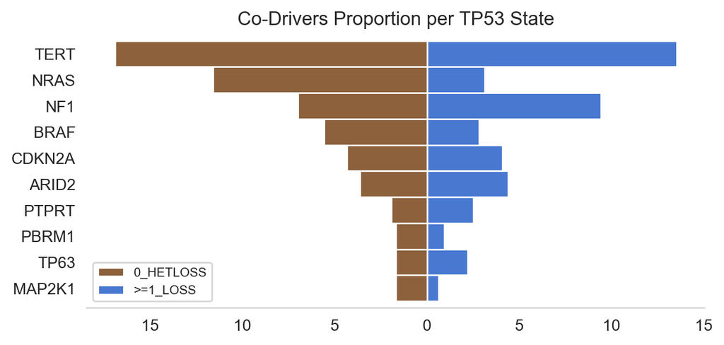

```python
fig=plt.figure(figsize=(7,7))
ax = plt.subplot2grid(shape=(2,1), loc=(0,0), colspan=1)
ax.spines['right'].set_visible(False)
ax.spines['left'].set_visible(False)
ax.spines['top'].set_visible(False)

co_drivers_losses[['proportion_1', 'proportion_2']].head(10)[::-1].plot.barh(stacked=True, ax=ax, width=1, color = [mc[5],mc[0]])
ax.legend(['0_HETLOSS', '>=1_LOSS'], fontsize=8)
ax.set_title('Co-Drivers Proportion per TP53 State')

plt.yticks(fontsize=10)
ax.set_ylabel('')
a=ax.get_xticks().tolist()
a = [20, 15, 10, 5, 0, 5, 10, 15, 20]
ax.set_xticklabels(a, fontsize=10)
plt.grid(b=None)

plt.show()
```

```python
co_drivers_mult_cnloh = create_co_drivers_table(master=master_no_wgd_cancer,
                                                group_type='tp53_group',
                                                group_1='>1muts',
                                                group_2='>=1_cnLOH')
co_drivers_mult_cnloh
```

| Hugo_Symbol | count_x | proportion_1 | count_y | proportion_2 |
| --- | --- | --- | --- | --- |
| TERT | 12 | -10.43 | 7 | 12.73 |
| NF1 | 9 | -7.83 | 8 | 14.55 |
| PTPRD | 6 | -5.22 | 2 | 3.64 |
| ARID2 | 4 | -3.48 | 3 | 5.45 |
| CDKN2A | 4 | -3.48 | 2 | 3.64 |
| GRIN2A | 3 | -2.61 | 3 | 5.45 |
| RB1 | 2 | -1.74 | 1 | 1.82 |
| FAM58A | 2 | -1.74 | 1 | 1.82 |
| STK19 | 2 | -1.74 | 1 | 1.82 |
| MGA | 1 | -0.87 | 1 | 1.82 |
| KRAS | 1 | -0.87 | 1 | 1.82 |
| ARID1A | 1 | -0.87 | 2 | 3.64 |
| BRAF | 1 | -0.87 | 2 | 3.64 |
| CTNNB1 | 1 | -0.87 | 1 | 1.82 |
| EPHA7 | 1 | -0.87 | 1 | 1.82 |
| APC | 1 | -0.87 | 1 | 1.82 |

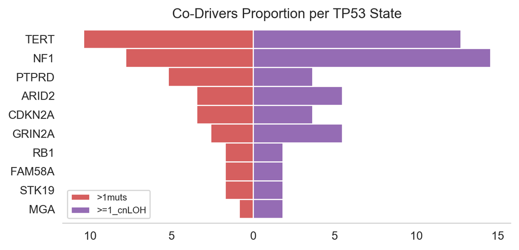

```python
fig=plt.figure(figsize=(7,7))
ax = plt.subplot2grid(shape=(2,1), loc=(0,0), colspan=1)
ax.spines['right'].set_visible(False)
ax.spines['left'].set_visible(False)
ax.spines['top'].set_visible(False)

co_drivers_mult_cnloh[['proportion_1', 'proportion_2']].head(10)[::-1].plot.barh(stacked=True, ax=ax, width=1, color = [mc[3],mc[4]])
ax.legend(['>1muts', '>=1_cnLOH'], fontsize=8)
ax.set_title('Co-Drivers Proportion per TP53 State')

plt.yticks(fontsize=10)
ax.set_ylabel('')
a=ax.get_xticks().tolist()
a = [15, 10, 5, 0, 5, 10, 15, 20]
ax.set_xticklabels(a, fontsize=10)
plt.grid(b=None)

plt.show()
```

```python
co_drivers_wt_loss = create_co_drivers_table(master=master_no_wgd_cancer,
                                                group_type='tp53_group',
                                                group_1='1_WILD_TYPE',
                                                group_2='>=1_LOSS')
co_drivers_wt_loss
```

| Hugo_Symbol | count_x | proportion_1 | count_y | proportion_2 |
| --- | --- | --- | --- | --- |
| TERT | 9 | -14.75 | 43 | 13.52 |
| NRAS | 4 | -6.56 | 10 | 3.14 |
| CDKN2A | 3 | -4.92 | 13 | 4.09 |
| ARID1A | 3 | -4.92 | 2 | 0.63 |
| NF1 | 3 | -4.92 | 30 | 9.43 |
| BRAF | 3 | -4.92 | 9 | 2.83 |
| RNF43 | 2 | -3.28 | 1 | 0.31 |
| RB1 | 2 | -3.28 | 2 | 0.63 |
| KIT | 2 | -3.28 | 4 | 1.26 |
| ARID2 | 2 | -3.28 | 14 | 4.40 |
| CDK4 | 1 | -1.64 | 1 | 0.31 |
| ANKRD11 | 1 | -1.64 | 2 | 0.63 |
| SF3B1 | 1 | -1.64 | 1 | 0.31 |
| APC | 1 | -1.64 | 2 | 0.63 |
| ATRX | 1 | -1.64 | 4 | 1.26 |
| NOTCH4 | 1 | -1.64 | 3 | 0.94 |
| B2M | 1 | -1.64 | 2 | 0.63 |
| KMT2B | 1 | -1.64 | 5 | 1.57 |
| CDK12 | 1 | -1.64 | 1 | 0.31 |
| KMT2A | 1 | -1.64 | 7 | 2.20 |
| CBL | 1 | -1.64 | 5 | 1.57 |
| AMER1 | 1 | -1.64 | 1 | 0.31 |
| FAT1 | 1 | -1.64 | 3 | 0.94 |
| DNMT3A | 1 | -1.64 | 1 | 0.31 |
| CRLF2 | 1 | -1.64 | 1 | 0.31 |

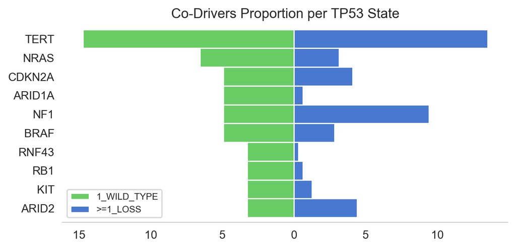

```python
fig=plt.figure(figsize=(7,7))
ax = plt.subplot2grid(shape=(2,1), loc=(0,0), colspan=1)
ax.spines['right'].set_visible(False)
ax.spines['left'].set_visible(False)
ax.spines['top'].set_visible(False)

co_drivers_wt_loss[['proportion_1', 'proportion_2']].head(10)[::-1].plot.barh(stacked=True, ax=ax, width=1, color = [mc[2],mc[0]])
ax.legend(['1_WILD_TYPE', '>=1_LOSS'], fontsize=8)
ax.set_title('Co-Drivers Proportion per TP53 State')

plt.yticks(fontsize=10)
ax.set_ylabel('')
a=ax.get_xticks().tolist()
a = [20, 15, 10, 5, 0, 5, 10, 15]
ax.set_xticklabels(a, fontsize=10)
plt.grid(b=None)

plt.show()
```

#### Comparison with WGD Cohort (WGD - TP53 - LOH)

```python
def get_major_codrivers(master: pd.DataFrame, maf: pd.DataFrame, head:int = 10):
    samples = master.Tumor_Id.tolist()
    maf_filtered = maf[maf.Tumor_Sample_Barcode.isin(samples)][maf['driver'] == True][maf['Hugo_Symbol'] != 'TP53']
    h = pd.DataFrame(maf_filtered[['Hugo_Symbol']].groupby(['Hugo_Symbol']).size())
    h.columns = ['count']
    h = h.sort_values(by='count', ascending=False).head(head)

    return(h)

def create_co_drivers_table_wgd(master_1: pd.DataFrame, master_2: pd.DataFrame, group_type:str,  group_1: str):
    master_group_1 = master_1[master_1[group_type] == group_1]
    co_drivers_group_1 = get_major_codrivers(master=master_group_1,
                        maf=maf_cohort_nowgd,
                       head=100)
    co_drivers_group_1['proportion_1'] = co_drivers_group_1.apply(lambda x: 100* round(x['count'] / co_drivers_group_1.sum().values[0], 4), axis=1)

    master_group_2 = master_2[master_2['tp53_count'] >=1][master_2['tp53_loh_status'] == True]
    co_drivers_group_2 = get_major_codrivers(master=master_group_2,
                        maf=maf_cohort_wgd,
                       head=100)
    co_drivers_group_2['proportion_2'] = co_drivers_group_2.apply(lambda x: 100* round(x['count'] / co_drivers_group_2.sum().values[0], 4), axis=1)

    co_drivers_groups = pd.merge(co_drivers_group_2, co_drivers_group_1, on='Hugo_Symbol')
    co_drivers_groups['proportion_2'] = - co_drivers_groups['proportion_2']

    return co_drivers_groups
```

```python
co_drivers_wgd_loss = create_co_drivers_table_wgd(master_1=master_no_wgd_cancer,
                            master_2=master_wgd_cancer,
                            group_type='tp53_group',
                            group_1='>=1_LOSS')
co_drivers_wgd_loss
```

| Hugo_Symbol | count_x | proportion_2 | count_y | proportion_1 |
| --- | --- | --- | --- | --- |
| TERT | 56 | -18.42 | 43 | 13.52 |
| BRAF | 22 | -7.24 | 9 | 2.83 |
| NF1 | 19 | -6.25 | 30 | 9.43 |
| NRAS | 16 | -5.26 | 10 | 3.14 |
| CDKN2A | 9 | -2.96 | 13 | 4.09 |
| ARID2 | 8 | -2.63 | 14 | 4.40 |
| RB1 | 7 | -2.30 | 2 | 0.63 |
| PTPRT | 6 | -1.97 | 8 | 2.52 |
| CBL | 6 | -1.97 | 5 | 1.57 |
| KNSTRN | 6 | -1.97 | 2 | 0.63 |
| FLT3 | 6 | -1.97 | 5 | 1.57 |
| ATRX | 5 | -1.64 | 4 | 1.26 |
| PTPRD | 5 | -1.64 | 6 | 1.89 |
| GRIN2A | 4 | -1.32 | 2 | 0.63 |
| RAC1 | 4 | -1.32 | 2 | 0.63 |
| SPEN | 4 | -1.32 | 4 | 1.26 |
| TP63 | 4 | -1.32 | 7 | 2.20 |
| KMT2B | 4 | -1.32 | 5 | 1.57 |
| ERBB4 | 3 | -0.99 | 3 | 0.94 |
| KMT2A | 3 | -0.99 | 7 | 2.20 |
| LATS2 | 2 | -0.66 | 1 | 0.31 |
| PARK2 | 2 | -0.66 | 1 | 0.31 |
| MAP2K1 | 2 | -0.66 | 2 | 0.63 |
| FAT1 | 2 | -0.66 | 3 | 0.94 |
| PIK3R1 | 2 | -0.66 | 1 | 0.31 |
| PTEN | 2 | -0.66 | 4 | 1.26 |
| RAF1 | 2 | -0.66 | 2 | 0.63 |
| STK19 | 2 | -0.66 | 1 | 0.31 |
| TET2 | 2 | -0.66 | 5 | 1.57 |
| CDK4 | 2 | -0.66 | 1 | 0.31 |
| APC | 2 | -0.66 | 2 | 0.63 |
| ARID1A | 2 | -0.66 | 2 | 0.63 |
| ARID1B | 2 | -0.66 | 1 | 0.31 |
| CASP8 | 2 | -0.66 | 1 | 0.31 |
| ERBB2 | 2 | -0.66 | 2 | 0.63 |
| DICER1 | 2 | -0.66 | 2 | 0.63 |
| CHEK2 | 2 | -0.66 | 2 | 0.63 |
| PTPN11 | 1 | -0.33 | 2 | 0.63 |
| PTCH1 | 1 | -0.33 | 1 | 0.31 |
| PMS1 | 1 | -0.33 | 1 | 0.31 |
| PBRM1 | 1 | -0.33 | 3 | 0.94 |
| PTPRS | 1 | -0.33 | 1 | 0.31 |
| PAK7 | 1 | -0.33 | 3 | 0.94 |
| B2M | 1 | -0.33 | 2 | 0.63 |
| ATR | 1 | -0.33 | 1 | 0.31 |
| RBM10 | 1 | -0.33 | 1 | 0.31 |
| SETD2 | 1 | -0.33 | 5 | 1.57 |
| ATM | 1 | -0.33 | 3 | 0.94 |
| STAG2 | 1 | -0.33 | 1 | 0.31 |
| TET1 | 1 | -0.33 | 2 | 0.63 |
| NTRK1 | 1 | -0.33 | 1 | 0.31 |
| HRAS | 1 | -0.33 | 2 | 0.63 |
| KIT | 1 | -0.33 | 4 | 1.26 |
| KDR | 1 | -0.33 | 3 | 0.94 |
| ERCC2 | 1 | -0.33 | 1 | 0.31 |
| GNAQ | 1 | -0.33 | 2 | 0.63 |
| ERCC3 | 1 | -0.33 | 1 | 0.31 |
| EZH2 | 1 | -0.33 | 1 | 0.31 |
| ANKRD11 | 1 | -0.33 | 2 | 0.63 |
| EPHA7 | 1 | -0.33 | 2 | 0.63 |
| EPHA3 | 1 | -0.33 | 2 | 0.63 |

[figure not shown]

```python
fig=plt.figure(figsize=(7,7))
ax = plt.subplot2grid(shape=(2,1), loc=(0,0), colspan=1)
ax.spines['right'].set_visible(False)
ax.spines['left'].set_visible(False)
ax.spines['top'].set_visible(False)

co_drivers_wgd_loss[['proportion_2', 'proportion_1']].head(15)[::-1].plot.barh(stacked=True, ax=ax, width=1, color = ['#7F8C8D',mc[0]])
ax.legend(['WGD - TP53 - LOH', '>=1_LOSS'], fontsize=8)
ax.set_title('Co-Drivers Proportion per TP53 State')

plt.yticks(fontsize=10)
ax.set_ylabel('')
a=ax.get_xticks().tolist()
a = [25, 20, 15, 10, 5, 0, 5, 10, 15, 20]
ax.set_xticklabels(a, fontsize=10)
plt.grid(b=None)

plt.show()
```

### Genome Instability Associated

```python
def get_master_codrivers(master: pd.DataFrame, maf: pd.DataFrame, symbol: str):
    samples = master.Tumor_Id.tolist()
    samples_final = maf[maf.Tumor_Sample_Barcode.isin(samples)][maf['Hugo_Symbol'] == symbol].Tumor_Sample_Barcode.tolist()

    master_filtered = master[master.Tumor_Id.isin(samples_final)]

    return master_filtered
```

#### TP53 Res

```python
master_no_wgd_cancer_res = master_no_wgd_cancer[master_no_wgd_cancer['tp53_res_group'] == 'tp53_res']
master_NF1 = get_master_codrivers(master=master_no_wgd_cancer_res,
                                   maf=maf_cohort_nowgd,
                                   symbol='NF1')

master_NRAS = get_master_codrivers(master=master_no_wgd_cancer_res,
                                   maf=maf_cohort_nowgd,
                                   symbol='NRAS')

master_TERT = get_master_codrivers(master=master_no_wgd_cancer_res,
                                   maf=maf_cohort_nowgd,
                                   symbol='TERT')

master_no_wgd_cancer_res['data'] = 'tp53_res'
master_NF1['data'] = 'NF1'
master_NRAS['data'] = 'NRAS'
master_TERT['data'] = 'TERT'

masters = [master_no_wgd_cancer_res, master_NRAS, master_NF1, master_TERT]
allMasters = pd.concat(masters)
```

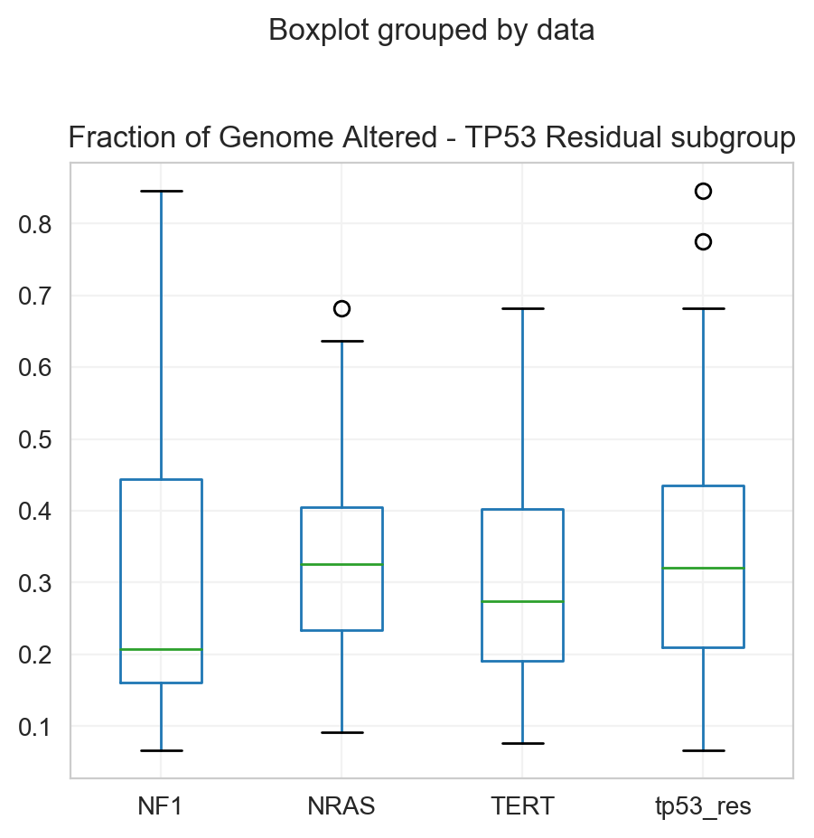

```python
fig=plt.figure(figsize=(5,10))
ax = plt.subplot2grid(shape=(2,1), loc=(0,0), colspan=1)
allMasters[['frac_genome_altered', 'data']].boxplot(by="data", ax=ax)
ax.set_title('Fraction of Genome Altered - TP53 Residual subgroup')
ax.set_xlabel('')
```

#### >=1_LOSS

```python
master_no_wgd_cancer_loss = master_no_wgd_cancer[master_no_wgd_cancer['tp53_group'] == '>=1_LOSS']
master_TERT = get_master_codrivers(master=master_no_wgd_cancer_loss,
                                   maf=maf_cohort_nowgd,
                                   symbol='TERT')

master_NRAS = get_master_codrivers(master=master_no_wgd_cancer_loss,
                                   maf=maf_cohort_nowgd,
                                   symbol='NRAS')

master_NF1 = get_master_codrivers(master=master_no_wgd_cancer_loss,
                                   maf=maf_cohort_nowgd,
                                   symbol='NF1')

master_BRAF = get_master_codrivers(master=master_no_wgd_cancer_loss,
                                   maf=maf_cohort_nowgd,
                                   symbol='BRAF')

master_no_wgd_cancer_loss['data'] = '>=1_LOSS'
master_TERT['data'] = 'TERT'
master_NRAS['data'] = 'NRAS'
master_NF1['data'] = 'NF1'
master_BRAF['data'] = 'BRAF'


masters = [master_no_wgd_cancer_loss, master_TERT, master_NRAS, master_NF1, master_BRAF ]
allMasters = pd.concat(masters)
```

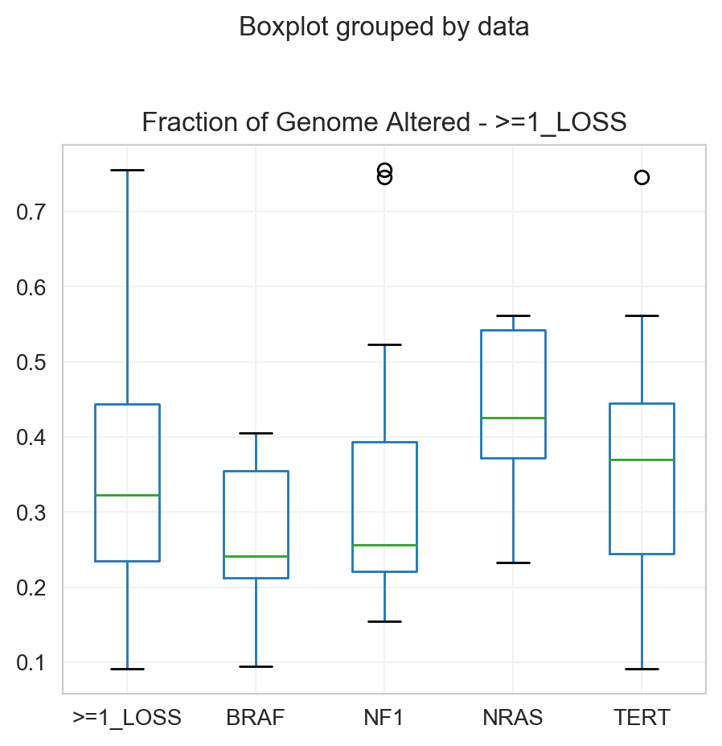

```python
fig=plt.figure(figsize=(5,10))
ax = plt.subplot2grid(shape=(2,1), loc=(0,0), colspan=1)
allMasters[['frac_genome_altered', 'data']].boxplot(by="data", ax=ax)
ax.set_title('Fraction of Genome Altered - >=1_LOSS')
ax.set_xlabel('')
```

#### 0_HETLOSS

```python
master_no_wgd_cancer_loss = master_no_wgd_cancer[master_no_wgd_cancer['tp53_group'] == '0_HETLOSS']
master_TERT = get_master_codrivers(master=master_no_wgd_cancer_loss,
                                   maf=maf_cohort_nowgd,
                                   symbol='TERT')

master_NRAS = get_master_codrivers(master=master_no_wgd_cancer_loss,
                                   maf=maf_cohort_nowgd,
                                   symbol='NRAS')

master_NF1 = get_master_codrivers(master=master_no_wgd_cancer_loss,
                                   maf=maf_cohort_nowgd,
                                   symbol='NF1')

master_BRAF = get_master_codrivers(master=master_no_wgd_cancer_loss,
                                   maf=maf_cohort_nowgd,
                                   symbol='BRAF')

master_no_wgd_cancer_loss['data'] = '0_HETLOSS'
master_TERT['data'] = 'TERT'
master_NRAS['data'] = 'NRAS'
master_NF1['data'] = 'NF1'
master_BRAF['data'] = 'BRAF'


masters = [master_no_wgd_cancer_loss, master_TERT, master_NRAS, master_NF1, master_BRAF ]
allMasters = pd.concat(masters)
```

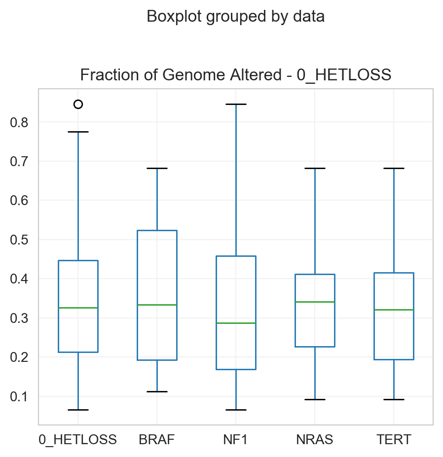

```python
fig=plt.figure(figsize=(5,10))
ax = plt.subplot2grid(shape=(2,1), loc=(0,0), colspan=1)
allMasters[['frac_genome_altered', 'data']].boxplot(by="data", ax=ax)
ax.set_title('Fraction of Genome Altered - 0_HETLOSS')
ax.set_xlabel('')
```

## CCF / VAF Analysis

Same here we take only samples with exactly 1 tp53 mutation (*master_hotspot*).

We have to define groups for CCF to see if there are differences between those groups. To have an idea of the CCF distribution we show here the distribution coming from the *cancer_panel*.

[figure not shown]

We see that our tp53_ccf distribution is very high for all subgroups except for *1_WILD_TYPE*.

It will be hard to cut the cohort based on the CCF. Let's try and see the size of the subcohorts:

```python
master_ccf = master_no_wgd_cancer[(master_no_wgd_cancer['tp53_count'] == 1) | (master_no_wgd_cancer['tp53_group'] == '0_HETLOSS')]
```

```python
thr_ccf_1 = 0.90 ; thr_ccf_2 = 0.95

def ccf_subgroup(x):
    if x.tp53_ccf_1 <= thr_ccf_1: return 'low'
    elif x.tp53_ccf_1 <= thr_ccf_2: return 'medium'
    elif x.tp53_ccf_1 > thr_ccf_2: return 'high'

master_ccf['ccf_group'] = master_ccf.apply(ccf_subgroup, axis=1)
get_groupby(master_ccf, 'ccf_group', 'count')
```

| ccf_group | count |
| --- | --- |
| high | 50 |
| low | 11 |
| medium | 7 |

```python
thr_vaf_1 = 0.3 ; thr_vaf_2 = 0.4

def vaf_subgroup(x):
    if x.tp53_vaf_1 <= thr_vaf_1: return 'low'
    elif x.tp53_vaf_1 <= thr_vaf_2: return 'medium'
    elif x.tp53_vaf_1 > thr_vaf_2: return 'high'

master_ccf['vaf_group'] = master_ccf.apply(vaf_subgroup, axis=1)
get_groupby(master_ccf, 'vaf_group', 'count')
```

| vaf_group | count |
| --- | --- |
| high | 25 |
| low | 24 |
| medium | 19 |

### VAF Analysis

#### No VAF Cut

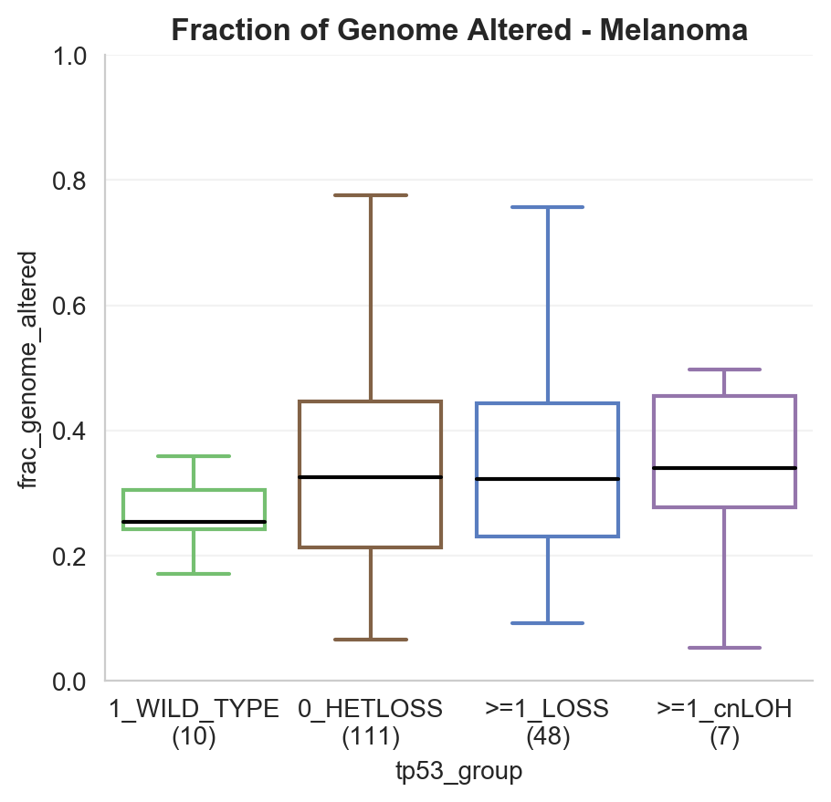

|  | 0 | 1 | 2 |
| --- | --- | --- | --- |
| 0 |  | size | frac_genome_altered |
| 1 | 0_HETLOSS | 111 | 0.326 |
| 2 | 1_WILD_TYPE | 10 | 0.254 |
| 3 |  | Statistics | p-value |
| 4 |  | 1.21434 | 0.224619 |

```python
fig, ax = boxplot_sampletype(df=master_ccf,
                  group='tp53_group',
                  palette=palette,
                  order=['1_WILD_TYPE','0_HETLOSS', '>=1_LOSS', '>=1_cnLOH'],
                  metrics='frac_genome_altered',
                  figsize=(5,10),
                  title='Fraction of Genome Altered - {}'.format(cancer),
                  xlim=[0,1])
plt.show()

get_statistics(df=master_ccf,
               group='tp53_group',
               metrics='frac_genome_altered',
               group_list=['0_HETLOSS', '1_WILD_TYPE'])
```

#### Low VAF

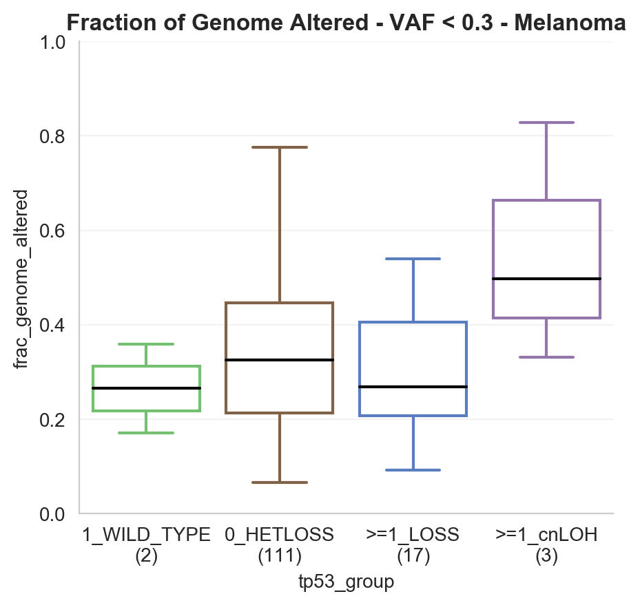

|  | 0 | 1 | 2 |
| --- | --- | --- | --- |
| 0 |  | size | frac_genome_altered |
| 1 | 1_WILD_TYPE | 2 | 0.265 |
| 2 | >=1_LOSS | 17 | 0.269 |
| 3 |  | Statistics | p-value |
| 4 |  | -0.398527 | 0.690242 |

```python
master_low = master_ccf[(master_ccf['vaf_group'] == 'low') | (master_ccf['tp53_group'] == '0_HETLOSS')]

fig, ax = boxplot_sampletype(df=master_low,
                  group='tp53_group',
                  palette=palette,
                  order=['1_WILD_TYPE','0_HETLOSS', '>=1_LOSS', '>=1_cnLOH'],
                  metrics='frac_genome_altered',
                  figsize=(5,10),
                  title='Fraction of Genome Altered - VAF < {} - {}'.format(thr_vaf_1,cancer),
                  xlim=[0,1])
plt.show()

get_statistics(df=master_low,
               group='tp53_group',
               metrics='frac_genome_altered',
               group_list=['1_WILD_TYPE', '>=1_LOSS'])
```

#### Medium VAF

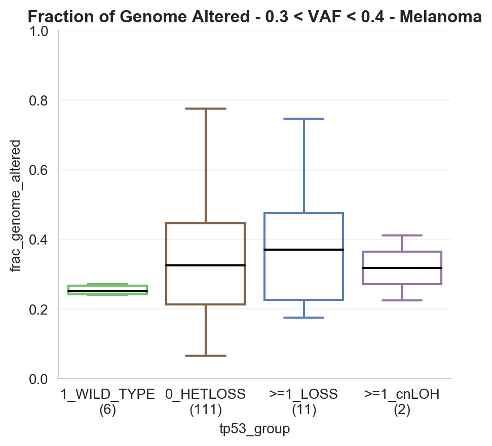

|  | 0 | 1 | 2 |
| --- | --- | --- | --- |
| 0 |  | size | frac_genome_altered |
| 1 | 1_WILD_TYPE | 6 | 0.251 |
| 2 | 0_HETLOSS | 111 | 0.326 |
| 3 |  | Statistics | p-value |
| 4 |  | -1.54462 | 0.122437 |

```python
master_med = master_ccf[(master_ccf['vaf_group'] == 'medium') | (master_ccf['tp53_group'] == '0_HETLOSS')]

fig, ax = boxplot_sampletype(df=master_med,
                  group='tp53_group',
                  palette=palette,
                  order=['1_WILD_TYPE', '0_HETLOSS', '>=1_LOSS', '>=1_cnLOH'],
                  metrics='frac_genome_altered',
                  figsize=(5,10),
                  title='Fraction of Genome Altered - {} < VAF < {} - {}'.format(thr_vaf_1,thr_vaf_2,cancer),
                  xlim=[0,1])
plt.show()

get_statistics(df=master_med,
               group='tp53_group',
               metrics='frac_genome_altered',
               group_list=['1_WILD_TYPE', '0_HETLOSS'])
```

#### High VAF

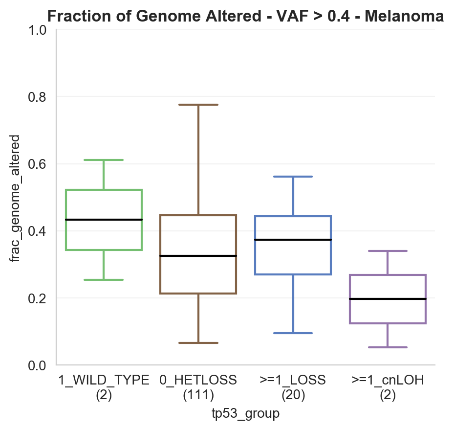

|  | 0 | 1 | 2 |
| --- | --- | --- | --- |
| 0 |  | size | frac_genome_altered |
| 1 | 1_WILD_TYPE | 2 | 0.4325 |
| 2 | 0_HETLOSS | 111 | 0.326 |
| 3 |  | Statistics | p-value |
| 4 |  | 0.63148 | 0.527727 |

```python
master_high = master_ccf[(master_ccf['vaf_group'] == 'high') | (master_ccf['tp53_group'] == '0_HETLOSS')]

fig, ax = boxplot_sampletype(df=master_high,
                  group='tp53_group',
                  palette=palette,
                  order=['1_WILD_TYPE', '0_HETLOSS', '>=1_LOSS', '>=1_cnLOH'],
                  metrics='frac_genome_altered',
                  figsize=(5,10),
                  title='Fraction of Genome Altered - VAF > {} - {}'.format(thr_vaf_2,cancer),
                  xlim=[0,1])
plt.show()

get_statistics(df=master_high,
               group='tp53_group',
               metrics='frac_genome_altered',
               group_list=['1_WILD_TYPE', '0_HETLOSS'])
```

### CCF Analysis

#### No CCF Cut

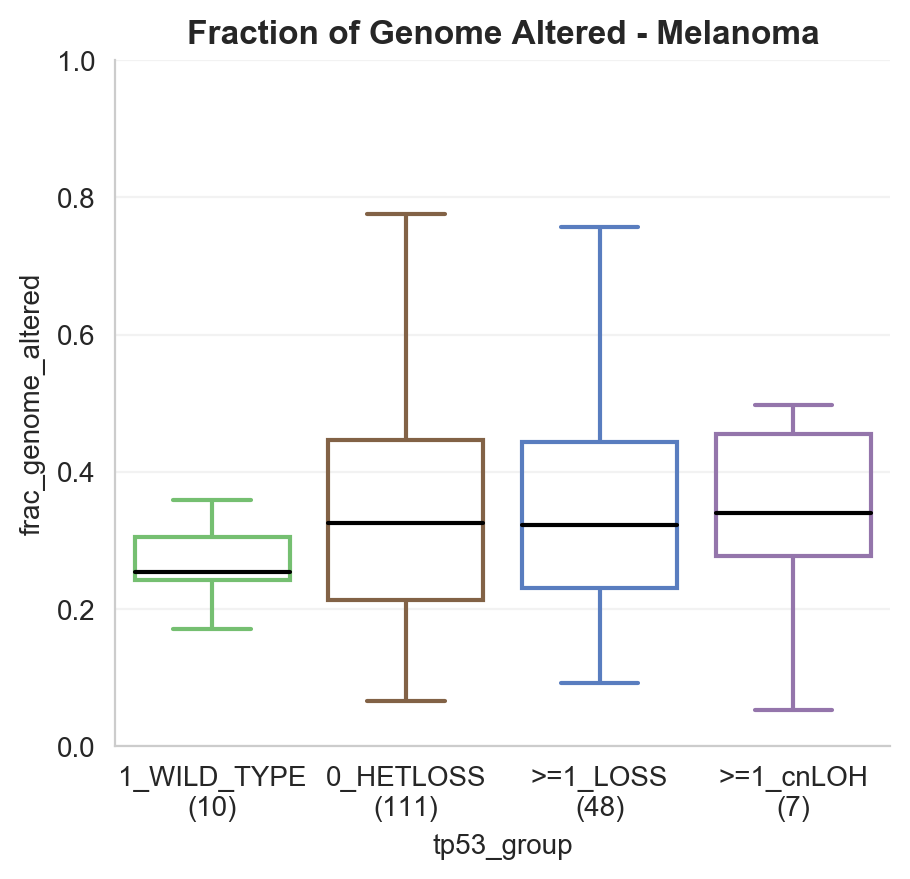

|  | 0 | 1 | 2 |
| --- | --- | --- | --- |
| 0 |  | size | frac_genome_altered |
| 1 | 0_HETLOSS | 111 | 0.326 |
| 2 | 1_WILD_TYPE | 10 | 0.254 |
| 3 |  | Statistics | p-value |
| 4 |  | 1.21434 | 0.224619 |

```python
fig, ax = boxplot_sampletype(df=master_ccf,
                  group='tp53_group',
                  palette=palette,
                  order=['1_WILD_TYPE','0_HETLOSS', '>=1_LOSS', '>=1_cnLOH'],
                  metrics='frac_genome_altered',
                  figsize=(5,10),
                  title='Fraction of Genome Altered - {}'.format(cancer),
                  xlim=[0,1])
plt.show()

get_statistics(df=master_ccf,
               group='tp53_group',
               metrics='frac_genome_altered',
               group_list=['0_HETLOSS', '1_WILD_TYPE'])
```

#### Low CCF

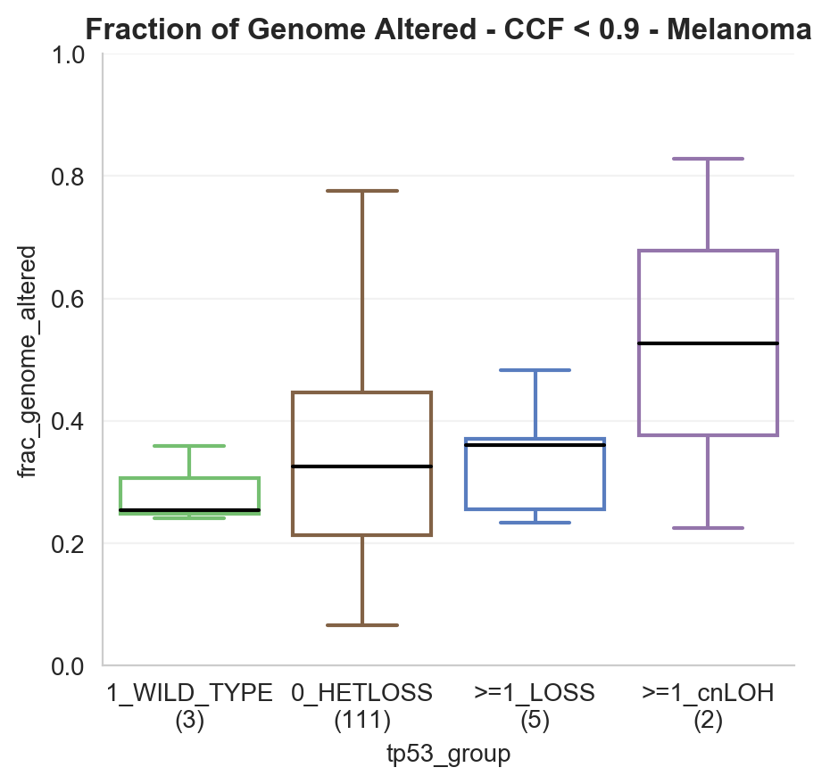

|  | 0 | 1 | 2 |
| --- | --- | --- | --- |
| 0 |  | size | frac_genome_altered |
| 1 | 1_WILD_TYPE | 3 | 0.254 |
| 2 | 0_HETLOSS | 111 | 0.326 |
| 3 |  | Statistics | p-value |
| 4 |  | -0.539908 | 0.589261 |

```python
master_low = master_ccf[(master_ccf['ccf_group'] == 'low') | (master_ccf['tp53_group'] == '0_HETLOSS')]

fig, ax = boxplot_sampletype(df=master_low,
                  group='tp53_group',
                  palette=palette,
                  order=['1_WILD_TYPE','0_HETLOSS', '>=1_LOSS', '>=1_cnLOH'],
                  metrics='frac_genome_altered',
                  figsize=(5,10),
                  title='Fraction of Genome Altered - CCF < {} - {}'.format(thr_ccf_1,cancer),
                  xlim=[0,1])
plt.show()

get_statistics(df=master_low,
               group='tp53_group',
               metrics='frac_genome_altered',
               group_list=['1_WILD_TYPE', '0_HETLOSS'])
```

#### Medium CCF

[output not shown]

[output cut: 23 more lines]

[output not shown]

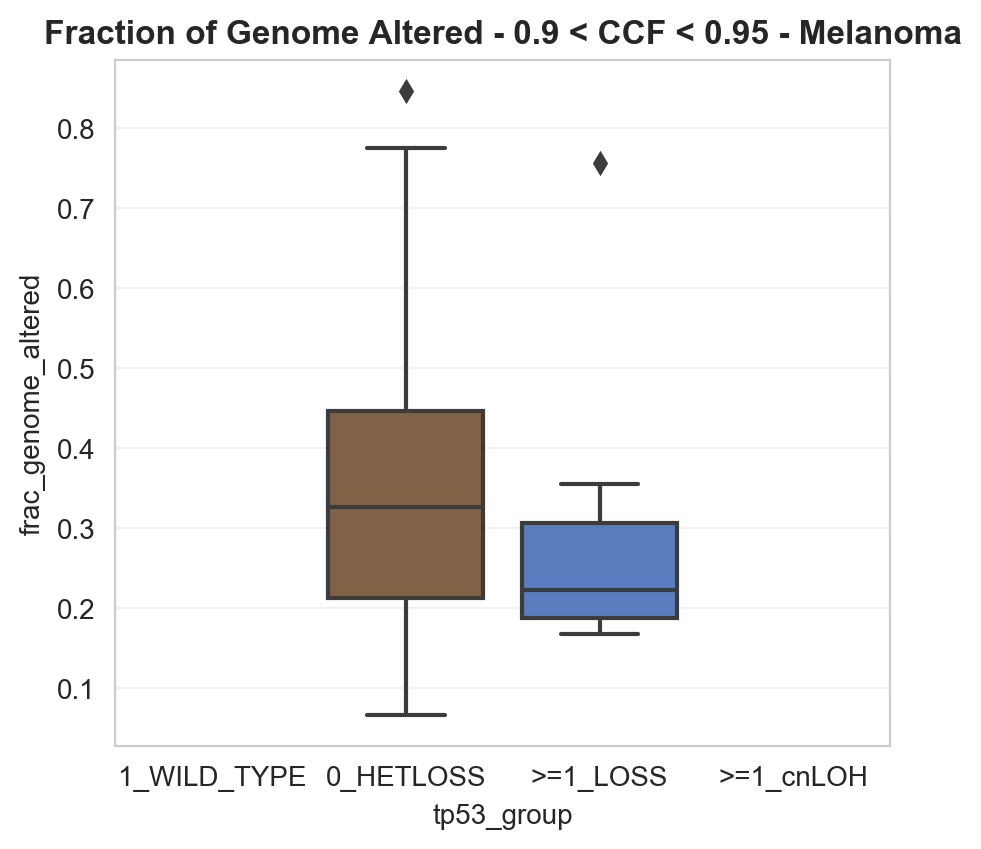

```python
master_med = master_ccf[(master_ccf['ccf_group'] == 'medium') | (master_ccf['tp53_group'] == '0_HETLOSS')]

fig, ax = boxplot_sampletype(df=master_med,
                  group='tp53_group',
                  palette=palette,
                  order=['1_WILD_TYPE', '0_HETLOSS', '>=1_LOSS', '>=1_cnLOH'],
                  metrics='frac_genome_altered',
                  figsize=(5,10),
                  title='Fraction of Genome Altered - {} < CCF < {} - {}'.format(thr_ccf_1,thr_ccf_2,cancer),
                  xlim=[0,1])
plt.show()

get_statistics(df=master_med,
               group='tp53_group',
               metrics='frac_genome_altered',
               group_list=['1_WILD_TYPE', '0_HETLOSS'])
```

#### High CCF

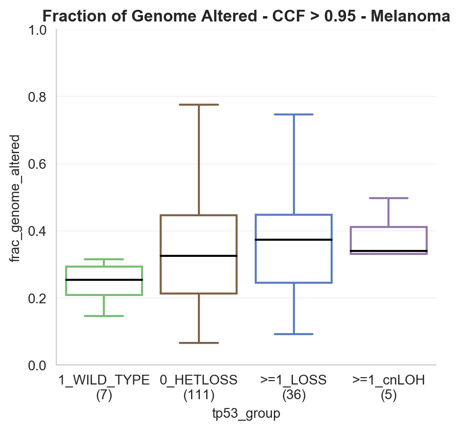

|  | 0 | 1 | 2 |
| --- | --- | --- | --- |
| 0 |  | size | frac_genome_altered |
| 1 | 1_WILD_TYPE | 7 | 0.254 |
| 2 | 0_HETLOSS | 111 | 0.326 |
| 3 |  | Statistics | p-value |
| 4 |  | -1.12213 | 0.261808 |

```python
master_high = master_ccf[(master_ccf['ccf_group'] == 'high') | (master_ccf['tp53_group'] == '0_HETLOSS')]

fig, ax = boxplot_sampletype(df=master_high,
                  group='tp53_group',
                  palette=palette,
                  order=['1_WILD_TYPE', '0_HETLOSS', '>=1_LOSS', '>=1_cnLOH'],
                  metrics='frac_genome_altered',
                  figsize=(5,10),
                  title='Fraction of Genome Altered - CCF > {} - {}'.format(thr_ccf_2,cancer),
                  xlim=[0,1])
plt.show()

get_statistics(df=master_high,
               group='tp53_group',
               metrics='frac_genome_altered',
               group_list=['1_WILD_TYPE', '0_HETLOSS'])
```

### Splitting on the different level of CCF / VAF

[output not shown]

[figure not shown]

```python
fig, ax = boxplot_sampletype(df=master_hotspot,
                  group='vaf_group',
                  palette={'low': tab10[0] , 'medium': tab10[1], 'high':tab10[2]},
                  order=['low', 'medium', 'high'],
                  metrics='frac_genome_altered',
                  figsize=(3,10),
                  title='Fraction of Genome Altered - VAF levels - {}'.format(cancer),
                  xlim=[0,1])
plt.show()

get_statistics(df=master_hotspot,
               group='vaf_group',
               metrics='frac_genome_altered',
               group_list=['low', 'medium'])
```

```python
fig, ax = boxplot_sampletype(df=master_hotspot,
                  group='ccf_group',
                  palette={'low': tab10[0] , 'medium': tab10[1], 'high':tab10[2]},
                  order=['low', 'medium', 'high'],
                  metrics='frac_genome_altered',
                  figsize=(3,10),
                  title='Fraction of Genome Altered - CCF levels - {}'.format(cancer),
                  xlim=[0,1])
plt.show()

get_statistics(df=master_hotspot,
               group='ccf_group',
               metrics='frac_genome_altered',
               group_list=['low', 'medium'])
```

[output not shown]